# SAVI case study — universal healthy baseline

STING signature and composition vs marginalised Immune Atlas null (blood PBMC)

Author

Affiliation

Chen Zhan

SAiGENCI, The University of Adelaide

Published

13 Jun 2026

Abstract

Companion to `SAVI_case_study.qmd`: same STING signature and composition workflow, but healthy atlas comparisons use a **universal marginalised null** (NA on sex, age decade, dataset, assay, ethnicity; `tissue_groups = blood`, Normal disease, **`offset = 0`**) rather than donor-matched metadata. Gene-level biomarker tests compare cohort **NB μ** (edgeR group MLE at `offset = 0`) to the posterior of the healthy **grand mean** (`posterior_linpred`, grid collapsed per draw; see `mu_test_report.qmd`). Composition uses pooled sccomp predictive draws.

# Introduction

[STING](https://en.wikipedia.org/wiki/Stimulator_of_interferon_genes)-associated vasculopathy with onset in infancy (**SAVI**) is caused by gain-of-function mutations in *STING1*. De Cevins *et al.* performed single-cell RNA-seq of PBMCs from SAVI patients and healthy controls, and an IFN-β time-course in healthy PBMCs, to dissect IFN-dependent and IFN-independent programmes. They highlight disease-associated monocytes and propose a **21-gene** transcriptomic signature of STING activation that is **enriched for TNF-α / NF-κB–related biology** and **filtered against IFN-β–induced genes** in monocytes and DCs (Figure 6; Table S6).

**Primary publication (open access):** de Cevins, C., *et al.* (2023). Single-cell RNA-sequencing of PBMCs from SAVI patients reveals disease-associated monocytes with elevated integrated stress response. *Cell Reports Medicine* **4**, 101333. https://doi.org/10.1016/j.xcrm.2023.101333 — PMC: https://pmc.ncbi.nlm.nih.gov/articles/PMC10772457/.

**Data:** scRNA-seq are deposited under superseries GSE226601: SAVI cohort GSE226598, IFN-β dataset GSE226572. Pseudobulk for this notebook is prepared in `dev/SAVI/data/prepare_data.R` from the GEO Seurat object.

**Scope of this document:** Same workflow as `SAVI_case_study.qmd`, but the **healthy atlas null is universal (marginalised)**, not personalised to donor metadata. Biomarker tests compare cohort **NB μ** to the healthy **grand-mean** posterior (`posterior_linpred`; see `mu_test_report.qmd`). Composition uses pooled sccomp predictive draws plus a **cohort-level sccomp group-means fit** on observed proportions (mirroring edgeR `~ 0 + group` for genes). GEO age/sex are still joined for **display and within-cohort** summaries only.

# Library setup

```r
# HPC / project R library (adjust if running elsewhere)
.libPaths("/hpcfs/users/a1237163/R/x86_64-pc-linux-gnu-library/4.5")

library(tibble)
library(tidyr)
library(dplyr)
library(tidySummarizedExperiment)
library(SummarizedExperiment)
library(S4Vectors)
library(AnnotationDbi)
library(org.Hs.eg.db)
library(tidybulk)
library(glue)
library(purrr)
library(furrr)
library(future)
library(lobstr)
library(posterior)
library(progressr)
library(brms)
library(poco)
library(tidyverse)
library(ggplot2)
library(forcats)
library(patchwork)
library(pheatmap)
library(RColorBrewer)
library(targets)
library(stringr)
library(Seurat)
library(tidyseurat)
library(edgeR)
```

# STING activation signature (21 genes)

The symbols below follow **Table S6** / Figure 6 in de Cevins *et al.* (2023). We map HGNC symbols to Ensembl via `org.Hs.eg.db` for overlap with the reference model feature space; **lncRNAs and some readthrough ids** may return `NA` here even when present in the single-cell count matrix — those rows are dropped from the `targets`-based extraction unless you supply Ensembl ids manually.

```r
sting_signature_21 <- tibble(
  gene = c(
    "AC253572.2",
    "ADRB2",
    "ANKRD28",
    "ANXA1",
    "AQP9",
    "AZIN1-AS1",
    "IL1B",
    "JARID2",
    "KLF4",
    "MIR4435-2HG",
    "OTUD1",
    "PLAUR",
    "PTGS2",
    "PTX3",
    "SELENOK",
    "TGIF1",
    "TREM1",
    "TSC22D2",
    "ZBTB43",
    "ZFP36L2",
    "ZNF503"
  )
) |>
  mutate(
    .feature = AnnotationDbi::mapIds(
      org.Hs.eg.db::org.Hs.eg.db,
      keys = gene,
      column = "ENSEMBL",
      keytype = "SYMBOL",
      multiVals = "first"
    )
  )

sting_signature_21
```

| gene | .feature |
| --- | --- |
| AC253572.2 | NA |
| ADRB2 | ENSG00000169252 |
| ANKRD28 | ENSG00000206560 |
| ANXA1 | ENSG00000135046 |
| AQP9 | ENSG00000103569 |
| AZIN1-AS1 | NA |
| IL1B | ENSG00000125538 |
| JARID2 | ENSG00000008083 |
| KLF4 | ENSG00000136826 |
| MIR4435-2HG | ENSG00000172965 |

[output cut: 11 more lines]

# Reference model store (`targets`)

Posterior HCA models live under `params$model_store_root`, in a subfolder named after the harmonised cell type (here `V1_monocytic` when `params$target_cell_type` is `"monocytic"`). Branch metadata encodes which Ensembl gene each `estimates_chunk_*` target belongs to (`Gene:___ENSG...___` in the recorded warning field).

```r
model_path <- file.path(
  params$model_store_root,
  paste0("V1_", params$target_cell_type)
)

model_meta <-
  targets::tar_meta(
    starts_with("estimates_chunk_"),
    store = file.path(model_path, "_targets")
  ) |>
  dplyr::filter(type == "branch") |>
  mutate(
    .feature = stringr::str_extract(
      warnings,
      "(?<=Gene:___)ENSG\\d+(?=___)"
    )
  )

# How many of the 21 (with successful SYMBOL→ENSEMBL map) appear in the store?
n_sig_in_store <- sum(sting_signature_21$.feature %in% model_meta$.feature, na.rm = TRUE)
n_sig_mapped <- sum(!is.na(sting_signature_21$.feature))

tibble(
  signature_genes = nrow(sting_signature_21),
  mapped_to_ensembl = n_sig_mapped,
  present_in_targets_store = n_sig_in_store
)
```

| signature_genes | mapped_to_ensembl | present_in_targets_store |
| --- | --- | --- |
| 21 | 19 | 16 |

# Fit and compress `brms` models (optional, heavy)

Set **`params$run_fits: true`** when rendering (or in the YAML) to re-run extraction, posterior correlation partitioning, `poco::compress_brmsfit`, and `saveRDS`. By default this chunk is **skipped** and the next section loads `params$estimates_rds`.

For each gene: read the precomputed `estimates_chunk` from disk (`tar_read_raw()` from the **targets** package, same usage as `dev/posteriorHCA_brms_fit_compression_test.qmd`), strip large environments from the fit, optionally compress with `poco`, and record layout / fidelity metrics.

```r
# handlers(global = TRUE)
# handlers("progress")
#
# options(future.globals.maxSize = 5 * 1024^3)
#
# n_components <- params$n_components
# corr_threshold <- params$corr_threshold
#
# extract_one_biomarker <- function(ensg) {
#   estimates_chunk <-
#     model_meta |>
#     dplyr::filter(.feature == ensg) |>
#     dplyr::pull(name) |>
#     tar_read_raw(store = file.path(model_path, "_targets")) |>
#     dplyr::select(-tar_group) |>
#     mutate(
#       gene = sting_signature_21 |>
#         dplyr::filter(!is.na(.feature), .feature == ensg) |>
#         dplyr::pull(gene),
#       cell_type = params$target_cell_type,
#       brms_fit = purrr::map(brms_fit, poco::strip_brmsfit_envs)
#     )
#
#   fit_brms <- estimates_chunk$brms_fit[[1]]
#
#   posterior_cor <- poco::posterior_correlation(
#     fit_brms,
#     type = "correlation",
#     method = "pearson"
#   )
#   original_draws <- posterior::as_draws_matrix(fit_brms)
#
#   partition <- poco::partition_parameters_clusters(
#     posterior_cor,
#     threshold = corr_threshold,
#     min_size = 2L,
#     simple_output = FALSE
#   )
#
#   layout_tbl <- tibble(
#     n_components = n_components,
#     corr_threshold = corr_threshold,
#     n_blocks = length(partition$blocks),
#     block_size_max = if (length(partition$blocks)) max(lengths(partition$blocks)) else 0L,
#     block_size_med = if (length(partition$blocks)) {
#       as.integer(stats::median(lengths(partition$blocks)))
#     } else {
#       0L
#     },
#     n_remainder = length(partition$remainder)
#   )
#
#   compress_tic <- Sys.time()
#   compressed_blockwise <- tryCatch(
#     poco::compress_brmsfit(
#       brmsfit = fit_brms,
#       method = "mclust",
#       n_components = n_components,
#       partition = partition,
#       cluster_BPPARAM = 1L,
#       verbose = FALSE
#     ),
#     error = function(e) {
#       warning(
#         "compress_brmsfit failed: ",
#         conditionMessage(e),
#         call. = FALSE,
#         immediate. = TRUE
#       )
#       NULL
#     }
#   )
#   time_used <- as.numeric(difftime(Sys.time(), compress_tic, units = "secs"))
#
#   fid_blockwise <- if (is.null(compressed_blockwise)) {
#     NULL
#   } else {
#     tryCatch(
#       poco::evaluate_compression(
#         compressed_blockwise$compressed,
#         original_draws,
#         seed = 1L
#       ),
#       error = function(e) {
#         warning(
#           "evaluate_compression failed: ",
#           conditionMessage(e),
#           call. = FALSE,
#           immediate. = TRUE
#         )
#         NULL
#       }
#     )
#   }
#
#   if (is.null(compressed_blockwise)) {
#     layout_tbl <- layout_tbl |>
#       mutate(
#         compression_ok = FALSE,
#         time_used = NA_real_,
#         compression_rate = NA_real_,
#         energy_pct = NA_real_,
#         c2st_pct = NA_real_,
#         reproduction_pct = NA_real_
#       )
#   } else {
#     estimates_chunk$brms_fit_compressed <- list(compressed_blockwise)
#     layout_tbl <- layout_tbl |>
#       mutate(
#         compression_ok = TRUE,
#         time_used = time_used,
#         compression_rate =
#           as.numeric(lobstr::obj_size(compressed_blockwise)) /
#             as.numeric(lobstr::obj_size(fit_brms))
#       )
#   }
#
#   if (is.null(fid_blockwise)) {
#     layout_tbl <- layout_tbl |>
#       mutate(
#         energy_pct = NA_real_,
#         c2st_pct = NA_real_,
#         reproduction_pct = NA_real_
#       )
#   } else {
#     en <- fid_blockwise$metrics$energy$reproduction_pct
#     c2 <- fid_blockwise$metrics$c2st$reproduction_pct
#     layout_tbl <- layout_tbl |>
#       mutate(
#         energy_pct = if (is.null(en)) NA_real_ else en,
#         c2st_pct = if (is.null(c2)) NA_real_ else c2,
#         reproduction_pct = fid_blockwise$reproduction_pct
#       )
#   }
#
#   estimates_chunk |> tibble::add_column(layout_tbl)
# }
#
# sting_signature_21 |>
#   dplyr::filter(.feature %in% model_meta$.feature) |>
#   dplyr::pull(.feature) -> biomarkers
#
# with_progress({
#   p <- progressr::progressor(along = biomarkers)
#   sting_estimates_chunk <- purrr::map_dfr(biomarkers, function(ensg) {
#     p(sprintf("Processing %s", ensg))
#     extract_one_biomarker(ensg)
#   })
# })
#
# saveRDS(sting_estimates_chunk, params$estimates_rds)
```

# Loaded estimates (preview)

```r
sting_estimates_chunk <- readRDS(params$estimates_rds)

sting_estimates_chunk |>
  dplyr::select(.feature, gene, compression_ok, compression_rate, reproduction_pct) |>
  head(10)
```

| .feature | gene | compression_ok | compression_rate | reproduction_pct |
| --- | --- | --- | --- | --- |
| ENSG00000169252 | ADRB2 | TRUE | 0.4843511 | 80.02750 |
| ENSG00000206560 | ANKRD28 | TRUE | 0.4787770 | 84.20969 |
| ENSG00000135046 | ANXA1 | TRUE | 0.4876678 | 80.07188 |
| ENSG00000103569 | AQP9 | TRUE | 0.4810870 | 84.81937 |
| ENSG00000125538 | IL1B | TRUE | 0.4814599 | 64.58938 |
| ENSG00000008083 | JARID2 | TRUE | 0.4835099 | 87.73281 |
| ENSG00000136826 | KLF4 | TRUE | 0.4911848 | 63.16312 |
| ENSG00000165312 | OTUD1 | TRUE | 0.4826568 | 83.37562 |
| ENSG00000011422 | PLAUR | TRUE | 0.4766429 | 77.42219 |
| ENSG00000073756 | PTGS2 | TRUE | 0.4839802 | 82.66938 |

# SAVI pseudobulk and healthy reference samples

**SAVI object:** RDS produced by `prepare_data.R` — pseudobulk counts aggregated with Seurat `AggregateExpression` by **`Sample`** and **`CellType`** (see GEO object metadata for treatment and category).

**Reference:** `pseudobulk_sample` from the same monocytic `targets` store is a `SummarizedExperiment` whose count assay is backed by the shared **Zenodo `pseudobulk_se.h5ad`** path. Rows with **`offset == 0`** are interpreted as healthy baseline samples for merge and posterior comparison (analogous to the breast epithelial reference in `pam50_toy_model.qmd`).

**Merge (same idea as `pam50_toy_model.qmd` § merge-se):** `SAVI_pseudobulk_sobj` is a **Seurat** object whose **RNA assay counts are row-named by gene symbol**. We map symbols → **Ensembl** (deduplicated), build a `SummarizedExperiment` with **`sample_role = "savi_pseudobulk"`**, then **column-bind** with reference columns after intersecting **shared Ensembl ids** and **assay names**.

```r
SAVI_pseudobulk_sobj <-
  readRDS(params$savi_pseudobulk_rds) %>%
  filter(CellType == '17. Disease-associated monocytes')

pseudobulk_sample <- targets::tar_read(
  pseudobulk_sample,
  store = file.path(model_path, "_targets")
)

# Point DelayedArray/HDF5 backend to the local h5ad-backed matrix (path may differ on HPC)
pseudobulk_sample@assays@data@listData[["counts"]]@seed@seed@seed@filepath <-
  params$pseudobulk_h5ad

ref_sample <-
  pseudobulk_sample |>
  dplyr::filter(offset == 0)

SummarizedExperiment::colData(ref_sample)$sample_role <- "reference"

# --- SAVI: Seurat counts are rownames = gene symbols (see prepare_data.R) ---
counts_sym <- as.matrix(
  tryCatch(
    SeuratObject::LayerData(SAVI_pseudobulk_sobj, assay = "RNA", layer = "counts"),
    error = function(e) {
      Seurat::GetAssayData(SAVI_pseudobulk_sobj, assay = "RNA", slot = "counts")
    }
  )
)

sym <- rownames(counts_sym)
ensg <- AnnotationDbi::mapIds(
  org.Hs.eg.db::org.Hs.eg.db,
  keys = sym,
  column = "ENSEMBL",
  keytype = "SYMBOL",
  multiVals = "first"
)
keep <- !is.na(ensg) & !duplicated(ensg)
ensg <- ensg[keep]

counts_ens <- counts_sym[keep, , drop = FALSE]
rownames(counts_ens) <- ensg

cd_savi <- as.data.frame(SAVI_pseudobulk_sobj@meta.data)
rownames(cd_savi) <- colnames(counts_ens)
cd_savi$sample_role <- "savi_pseudobulk"
cd_savi$offset <- 0L
if (!"cell_type_unified_ensemble" %in% names(cd_savi)) {
  cd_savi$cell_type_unified_ensemble <- cd_savi$CellType
}

se_savi_ensembl <- SummarizedExperiment::SummarizedExperiment(
  assays = list(counts = counts_ens),
  colData = S4Vectors::DataFrame(cd_savi, row.names = colnames(counts_ens)),
  rowData = S4Vectors::DataFrame(
    gene_symbol = sym[keep],
    row.names = ensg
  )
)

# --- rbind-like merge of SE columns (intersect genes, union colData columns) ---
merge_summarized_experiments <- function(...) {
  ses <- list(...)
  assay_names <- Reduce(intersect, lapply(ses, SummarizedExperiment::assayNames))
  if (length(assay_names) == 0L) {
    stop("No shared assays between SummarizedExperiment objects.")
  }

  genes <- Reduce(intersect, lapply(ses, rownames))
  if (length(genes) == 0L) {
    stop("No shared rownames between SummarizedExperiment objects.")
  }

  ses <- lapply(ses, function(se) se[genes, , drop = FALSE])

  cds <- lapply(ses, function(se) as.data.frame(SummarizedExperiment::colData(se)))
  all_nms <- Reduce(union, lapply(cds, names))
  cds <- lapply(cds, function(cd) {
    missing <- setdiff(all_nms, names(cd))
    for (nm in missing) cd[[nm]] <- NA
    cd[, all_nms, drop = FALSE]
  })

  # Dense coercion: SAVI counts are an ordinary matrix; reference counts are often
  # HDF5Array/DelayedArray. Mixed cbind() hits bindCOLS() with no suitable method.
  assays <- stats::setNames(
    lapply(assay_names, function(an) {
      mats <- lapply(ses, function(se) {
        base::as.matrix(SummarizedExperiment::assay(se, an))
      })
      do.call(base::cbind, mats)
    }),
    assay_names
  )

  SummarizedExperiment::SummarizedExperiment(
    assays = assays,
    colData = S4Vectors::DataFrame(
      do.call(rbind, cds),
      row.names = unlist(lapply(ses, colnames), use.names = FALSE)
    ),
    rowData = SummarizedExperiment::rowData(ses[[1]])
  )
}

se_monocytic <- merge_summarized_experiments(
  se_savi_ensembl,
  ref_sample
)

# Copy abundance flag from reference rowData when a single .abundant* column exists
rd_ref <- as.data.frame(SummarizedExperiment::rowData(ref_sample))
abundant_cols <- grep("^\\.abundant", names(rd_ref), value = TRUE)
if (length(abundant_cols) >= 1L) {
  ac <- abundant_cols[[1]]
  SummarizedExperiment::rowData(se_monocytic)$.abundant <-
    SummarizedExperiment::rowData(ref_sample)[rownames(se_monocytic), ac, drop = TRUE]
}

tibble::tibble(
  n_features = nrow(se_monocytic),
  n_samples = ncol(se_monocytic),
  n_savi = sum(SummarizedExperiment::colData(se_monocytic)$sample_role == "savi_pseudobulk"),
  n_reference = sum(SummarizedExperiment::colData(se_monocytic)$sample_role == "reference")
)
```

| n_features | n_samples | n_savi | n_reference |
| --- | --- | --- | --- |
| 9625 | 18 | 17 | 1 |

```r
ref_sample_name <-
  se_monocytic %>%
  colData() %>%
  as.data.frame() %>%
  filter(sample_role == "reference") %>%
  rownames()

se_monocytic <-
  se_monocytic %>%
  tidybulk::scale_abundance(
    method = "TMMwsp",
    reference_sample = ref_sample_name
  ) %>%
  mutate(offset = log(1 / multiplier))
```

# SAVI sample annotations (GEO GSE226598)

Per-sample metadata (age, sex, 10x library batch, GSM accession) is taken from the GEO **series matrix** for GSE226598 (same fields as the GEO web “Sample characteristics” table). Each GSM links to its own GEO sample page. In **this** notebook those fields are used for **tables, labels, and within-cohort** plots only — **not** for the Immune Atlas healthy null (see scope above).

After `scale_abundance`, we add harmonised columns for downstream models:

- **`tissue_groups`**: `"blood"` for SAVI pseudobulk columns only (PBMC in the study).
- **`sex`**, **`age_years`**: GEO values; **C1**, **C2** (“Adult”) and **P5_STING** (“Ped”) get **imputed numeric years** (see below) so `age_decade` / models can run without `NA`.
- **`age_decade`**: `as.character(ceiling(age_years / 10))` for SAVI once **`age_years`** is set (including imputed).
- **`age_group`**: `"pediatric"` if `age_years < 18`, else `"adult"` (SAVI columns only).
- **`age_decade_model`**: same as **`age_decade`** here (decade index from imputed / observed years).
- **`age_imputed`**: `TRUE` when **`age_years`** was filled by the rule below, not present as a number in GEO.

### Interpreting GEO **“Adult”** (C1, C2) and **“Ped”** (P5)

The cohort in de Cevins *et al.* (2023) comprises **five SAVI patients** and **seven healthy controls** (Figure 1A; GEO GSE226598). GEO lists **“age: Adult”** for **C1** / **C2** and **“age: Ped”** for **P5_STING** without a year.

**Imputation used in this notebook** (rounded integers, documented for reproducibility):

| Sample(s) | GEO label | Imputed `age_years` | Rationale |
| --- | --- | --- | --- |
| **C1**, **C2** | Adult | **35** | Mean of adult controls with numeric ages in the same series (**C8** 36 y, **C9** 35 y), aligned with matched adult controls. |
| **P5_STING** | Ped | **8** | Central value among other paediatric SAVI / control ages in GEO for this series (e.g. P1 4 y, P4 7–9 y, P6 8–10 y). |

All other donors keep **GEO-reported** ages. **`age_imputed`** is `TRUE` only for **C1**, **C2**, and **P5_STING**. Replace these constants if you obtain exact ages from authors or supplements.

- **`sex`**, **`assay_groups`**, **`assay_groups___altered`**: after GEO join, values are **harmonised to the Immune Atlas / posteriorHCA vocabulary** (same as `posteriorHCA::expr_predict()` / `Introduction` vignette: **`male`**, **`female`**, **`unknown`**; assay **`10x Genomics 3`**). GEO still uses **M**/**F** and Chromium **3′ v2**/**v3** batches in the series matrix; we do not keep the long Chromium strings in `colData` because the reference model was trained on short **`assay_groups`** labels.
- **`geo_accession`**, **`geo_sample_url`**: GSM id and direct GEO sample link (same pattern as the series page GSE226598).

```r
# Tibble from GEO series matrix GSE226598_series_matrix.txt.gz (Sample_title,
# Sample_geo_accession, age / Sex / batch rows). Series:
# https://www.ncbi.nlm.nih.gov/geo/query/acc.cgi?acc=GSE226598
geo_tbl <- tibble::tribble(
  ~Sample,              ~gse_accession, ~gse_age_years, ~gse_sex, ~gse_sting_batch,
  "C10",                "GSM7079979",            10,  "M",  "STING2",
  "C11",                "GSM7079980",            16,  "M",  "STING2",
  "C1",                 "GSM7079981",            NA,  "M",  "STING3",
  "C2",                 "GSM7079982",            NA,  "M",  "STING3",
  "C7",                 "GSM7079983",             5,  "F",  "STING1",
  "C8_aunt_P1_STING",   "GSM7079984",            36,  "F",  "STING1",
  "C9_mother_P1_STING", "GSM7079985",            35,  "F",  "STING1",
  "P1_STING_ht",        "GSM7079986",             4,  "F",  "STING1",
  "P1_STING_ht_T",      "GSM7079987",             8,  "F",  "STING1",
  "P1_STING_ht_T2",     "GSM7079988",             8,  "F",  "STING1",
  "P2_STING_ht",        "GSM7079989",            31,  "M",  "STING1",
  "P2_STING_ht_T",      "GSM7079990",            34,  "M",  "STING1",
  "P4_STING_ht",        "GSM7079991",             7,  "M",  "STING2",
  "P4_STING_ht_T",      "GSM7079992",             9,  "M",  "STING2",
  "P5_STING",           "GSM7079993",            NA,  "M",  "STING3",
  "P6_STING_ht",        "GSM7079994",             8,  "M",  "STING2",
  "P6_STING_ht_T",      "GSM7079995",            10,  "M",  "STING2"
) |>
  dplyr::mutate(
    # Raw GEO had NA for "Adult" (C1, C2) and "Ped" (P5); impute for modelling (see prose).
    gse_age_imputed = is.na(.data$gse_age_years),
    gse_age_years = dplyr::coalesce(
      .data$gse_age_years,
      dplyr::case_when(
        .data$Sample %in% c("C1", "C2") ~ 35,
        .data$Sample == "P5_STING" ~ 8,
        TRUE ~ NA_real_
      )
    )
  ) |>
  dplyr::mutate(
    gse_geo_sample_url = sprintf(
      "https://www.ncbi.nlm.nih.gov/geo/query/acc.cgi?acc=%s",
      .data$gse_accession
    )
  ) |>
  dplyr::select(
    "Sample",
    "gse_accession",
    "gse_geo_sample_url",
    "gse_age_years",
    "gse_age_imputed",
    "gse_sex"
  )

cd <- SummarizedExperiment::colData(se_monocytic) |> as.data.frame()
rn <- rownames(cd)

if (!"Sample" %in% names(cd)) {
  stop("colData must contain `Sample` (from SAVI pseudobulk) to join GEO metadata.")
}

if (!"tissue_groups" %in% names(cd)) {
  cd$tissue_groups <- NA_character_
}
if (!"age_years" %in% names(cd)) {
  cd$age_years <- NA_real_
}
if (!"sex" %in% names(cd)) {
  cd$sex <- NA_character_
}
if (!"assay_groups" %in% names(cd)) {
  cd$assay_groups <- NA_character_
}
if (!"assay_groups___altered" %in% names(cd)) {
  cd$assay_groups___altered <- NA_character_
}

cd <- cd |>
  dplyr::left_join(geo_tbl, by = "Sample")

miss_geo <- is.na(cd$gse_accession) & cd$sample_role == "savi_pseudobulk"
if (any(miss_geo, na.rm = TRUE)) {
  warning(
    "SAVI columns with no GEO match (check `Sample` vs GEO Sample_title): ",
    paste(unique(cd$Sample[miss_geo]), collapse = ", ")
  )
}

sex_ref <- if ("Sex" %in% names(cd)) cd$Sex else rep(NA_character_, nrow(cd))

cd <- cd |>
  dplyr::mutate(
    tissue_groups = dplyr::if_else(
      .data$sample_role == "savi_pseudobulk",
      "blood",
      .data$tissue_groups
    ),
    sex = dplyr::case_when(
      .data$sample_role == "savi_pseudobulk" ~ .data$gse_sex,
      TRUE ~ dplyr::coalesce(.data$sex, sex_ref)
    ),
    age_years = dplyr::case_when(
      .data$sample_role == "savi_pseudobulk" ~ .data$gse_age_years,
      TRUE ~ .data$age_years
    ),
    age_decade = dplyr::if_else(
      is.na(.data$age_years),
      NA_character_,
      as.character(ceiling(.data$age_years / 10))
    ),
    age_group = dplyr::case_when(
      .data$sample_role != "savi_pseudobulk" ~ NA_character_,
      !is.na(.data$age_years) & .data$age_years < 18 ~ "pediatric",
      !is.na(.data$age_years) & .data$age_years >= 18 ~ "adult",
      TRUE ~ NA_character_
    ),
    age_decade_model = .data$age_decade,
    age_imputed = dplyr::if_else(
      .data$sample_role == "savi_pseudobulk",
      .data$gse_age_imputed,
      NA
    ),
    assay_groups = dplyr::if_else(
      .data$sample_role == "savi_pseudobulk",
      "10x Genomics 3",
      .data$assay_groups
    ),
    assay_groups___altered = dplyr::case_when(
      .data$sample_role == "savi_pseudobulk" ~ "10x Genomics 3",
      !is.na(.data$assay_groups___altered) ~ .data$assay_groups___altered,
      !is.na(.data$assay_groups) ~ .data$assay_groups,
      TRUE ~ NA_character_
    ),
    geo_accession = dplyr::if_else(
      .data$sample_role == "savi_pseudobulk",
      .data$gse_accession,
      NA_character_
    ),
    geo_sample_url = dplyr::if_else(
      .data$sample_role == "savi_pseudobulk",
      .data$gse_geo_sample_url,
      NA_character_
    )
  ) |>
  dplyr::select(
    -dplyr::any_of(c(
      "gse_accession",
      "gse_geo_sample_url",
      "gse_age_years",
      "gse_age_imputed",
      "gse_sex",
      "Sex"
    ))
  ) |>
  dplyr::mutate(
    sex = dplyr::case_when(
      is.na(.data$sex) ~ NA_character_,
      .data$sex %in% c("male", "female", "unknown") ~ as.character(.data$sex),
      toupper(trimws(as.character(.data$sex))) %in% c("M", "MALE") ~ "male",
      toupper(trimws(as.character(.data$sex))) %in% c("F", "FEMALE") ~ "female",
      TRUE ~ "unknown"
    )
  )

SummarizedExperiment::colData(se_monocytic) <- S4Vectors::DataFrame(cd, row.names = rn)

cd |>
  dplyr::filter(.data$sample_role == "savi_pseudobulk") |>
  dplyr::distinct(
    .data$Sample,
    .data$tissue_groups,
    .data$sex,
    .data$age_years,
    .data$age_decade,
    .data$age_group,
    .data$age_decade_model,
    .data$age_imputed,
    .data$assay_groups,
    .data$assay_groups___altered,
    .data$geo_accession,
    .data$geo_sample_url
  ) |>
  dplyr::arrange(.data$Sample)
```

| Sample | tissue_groups | sex | age_years | age_decade | age_group | age_decade_model | age_imputed | assay_groups | assay_groups___altered | geo_accession | geo_sample_url |
| --- | --- | --- | --- | --- | --- | --- | --- | --- | --- | --- | --- |
| C1 | blood | male | 35 | 4 | adult | 4 | TRUE | 10x Genomics 3 | 10x Genomics 3 | GSM7079981 | https://www.ncbi.nlm.nih.gov/geo/query/acc.cgi?acc=GSM7079981 |
| C10 | blood | male | 10 | 1 | pediatric | 1 | FALSE | 10x Genomics 3 | 10x Genomics 3 | GSM7079979 | https://www.ncbi.nlm.nih.gov/geo/query/acc.cgi?acc=GSM7079979 |
| C11 | blood | male | 16 | 2 | pediatric | 2 | FALSE | 10x Genomics 3 | 10x Genomics 3 | GSM7079980 | https://www.ncbi.nlm.nih.gov/geo/query/acc.cgi?acc=GSM7079980 |
| C2 | blood | male | 35 | 4 | adult | 4 | TRUE | 10x Genomics 3 | 10x Genomics 3 | GSM7079982 | https://www.ncbi.nlm.nih.gov/geo/query/acc.cgi?acc=GSM7079982 |
| C7 | blood | female | 5 | 1 | pediatric | 1 | FALSE | 10x Genomics 3 | 10x Genomics 3 | GSM7079983 | https://www.ncbi.nlm.nih.gov/geo/query/acc.cgi?acc=GSM7079983 |
| C8_aunt_P1_STING | blood | female | 36 | 4 | adult | 4 | FALSE | 10x Genomics 3 | 10x Genomics 3 | GSM7079984 | https://www.ncbi.nlm.nih.gov/geo/query/acc.cgi?acc=GSM7079984 |
| C9_mother_P1_STING | blood | female | 35 | 4 | adult | 4 | FALSE | 10x Genomics 3 | 10x Genomics 3 | GSM7079985 | https://www.ncbi.nlm.nih.gov/geo/query/acc.cgi?acc=GSM7079985 |
| P1_STING_ht | blood | female | 4 | 1 | pediatric | 1 | FALSE | 10x Genomics 3 | 10x Genomics 3 | GSM7079986 | https://www.ncbi.nlm.nih.gov/geo/query/acc.cgi?acc=GSM7079986 |
| P1_STING_ht_T | blood | female | 8 | 1 | pediatric | 1 | FALSE | 10x Genomics 3 | 10x Genomics 3 | GSM7079987 | https://www.ncbi.nlm.nih.gov/geo/query/acc.cgi?acc=GSM7079987 |
| P1_STING_ht_T2 | blood | female | 8 | 1 | pediatric | 1 | FALSE | 10x Genomics 3 | 10x Genomics 3 | GSM7079988 | https://www.ncbi.nlm.nih.gov/geo/query/acc.cgi?acc=GSM7079988 |

[output cut: 7 more lines]

GEO sample pages use the same host as the series record above; each **`geo_sample_url`** points to the corresponding GSM (e.g. patient / control library) listed under GSE226598.

# Biomarker testing helpers (grand-mean μ null)

Universal healthy baseline for biomarker tests: marginalise unknown covariates (`sex`, `age_decade`, `ethnicity`, `assay`) with **`build_newdata_grid()`**, fix `disease = Normal`, `tissue = blood`, **`offset = 0`**, and draw the NB location parameter μ via **`posterior_linpred(transform = FALSE)`**. Per posterior draw we collapse the grid with **`rowMeans`** → **`grand_mean_draws`** (uncertainty in the healthy *mean*; see `mu_test_report.qmd`). Cohort μ comes from edgeR (`mglmOneGroup` at the same `scale_abundance` offset).

```r
# Categorical levels for any predictor pulled from the brms fit's training
# frame. Used to expand newdata over training-set values when a covariate is
# unknown for a test sample.
fit_levels <- function(fit, var) {
  d <- fit$data
  if (is.null(d) || !var %in% names(d)) return(character(0))
  v <- d[[var]]
  lv <- if (is.factor(v)) levels(v) else sort(unique(as.character(v)))
  lv[!is.na(lv) & nzchar(lv)]
}

# Fixed dataset_id placeholder for the universal null (one draw population per gene).
universal_baseline_new_level_tag <- "__universal_baseline__"

# Universal healthy null: identical for every sample (offset = 0 reference scale).
newdata_universal_baseline <- function() {
  tibble::tibble(
    age_decade = NA_character_,
    sex = NA_character_,
    ethnicity_groups = NA_character_,
    assay_groups_altered = NA_character_,
    disease_groups_altered = "Normal",
    tissue_groups = "blood",
    offset = 0
  )
}

# Generic marginalisation API (aligned with SAVI_marginalize_FE_tuning.qmd).
build_newdata_grid <- function(
  fit,
  newdata,
  marginalize_over = c("sex", "age_decade", "ethnicity_groups", "assay_groups_altered"),
  required = c("tissue_groups", "offset", "disease_groups_altered"),
  new_level_cols = "dataset_id_altered",
  new_level_tag = universal_baseline_new_level_tag
) {
  stopifnot(NROW(newdata) == 1L)
  newdata <- tibble::as_tibble(newdata)

  is_blank <- function(v) {
    length(v) == 0L ||
      is.na(v[[1L]]) ||
      (is.character(v[[1L]]) && !nzchar(v[[1L]]))
  }

  fit_vars <- colnames(fit$data)

  for (col in required) {
    if (!col %in% fit_vars) next
    if (!col %in% names(newdata) || is_blank(newdata[[col]])) {
      stop(sprintf("Required predictor `%s` is missing or empty in newdata.", col))
    }
  }

  to_expand <- character(0)
  for (col in marginalize_over) {
    if (!col %in% fit_vars) next
    if (!col %in% names(newdata) || is_blank(newdata[[col]])) {
      to_expand <- c(to_expand, col)
    }
  }

  if (length(to_expand)) {
    levels_list <- lapply(to_expand, function(col) fit_levels(fit, col))
    names(levels_list) <- to_expand
    keep <- vapply(levels_list, length, integer(1L)) > 0L
    levels_list <- levels_list[keep]
    to_expand <- names(levels_list)
  }

  if (length(to_expand)) {
    grid <- do.call(tidyr::expand_grid, levels_list)
    rest <- newdata[, setdiff(names(newdata), to_expand), drop = FALSE]
    out <- dplyr::bind_cols(
      rest[rep(1L, nrow(grid)), , drop = FALSE],
      grid
    )
  } else {
    out <- newdata
  }

  for (col in new_level_cols) {
    if (col %in% fit_vars) out[[col]] <- new_level_tag
  }

  tibble::as_tibble(out)
}

stouffer_one_sided <- function(p, alternative = c("greater", "less")) {
  alternative <- match.arg(alternative)
  p <- p[is.finite(p) & p > 0 & p < 1]
  if (!length(p)) {
    return(NA_real_)
  }
  z <- stats::qnorm(p / 2, lower.tail = FALSE)
  if (alternative == "less") {
    z <- -z
  }
  stats::pnorm(sum(z) / sqrt(length(z)), lower.tail = FALSE)
}

test_cohort_ordering <- function(
  df,
  score_var,
  category_var = "Category",
  levels = c("CTRL", "SAVI_treated", "SAVI")
) {
  df <- df |>
    dplyr::filter(!is.na(.data[[category_var]])) |>
    dplyr::mutate(
      !!category_var := factor(.data[[category_var]], levels = levels)
    )

  score <- df[[score_var]]
  catf <- df[[category_var]]

  kw <- stats::kruskal.test(score ~ catf)
  pw <- stats::pairwise.wilcox.test(
    score,
    catf,
    alternative = "greater",
    p.adjust.method = "BH",
    exact = FALSE
  )
  ord <- as.integer(catf)
  tr <- stats::cor.test(ord, score, method = "spearman", alternative = "greater")

  list(
    kruskal_p = kw$p.value,
    pairwise_wilcox_bh = pw,
    spearman_trend_p = tr$p.value,
    spearman_rho = unname(tr$estimate)
  )
}

# Healthy NB location parameter mu (log scale) — grand-mean posterior per draw.
# Uses posterior_linpred(transform = FALSE), NOT posterior_epred (ZINB expected count).
brms_universal_mu_grand_mean_draws <- function(
  fit,
  newdata = newdata_universal_baseline(),
  marginalize_over = c("sex", "age_decade", "ethnicity_groups", "assay_groups_altered"),
  required = c("tissue_groups", "offset", "disease_groups_altered"),
  new_level_cols = "dataset_id_altered",
  new_level_tag = universal_baseline_new_level_tag,
  re_formula = NULL,
  allow_new_levels = TRUE,
  sample_new_levels = "gaussian",
  ndraws = NULL
) {
  nd_grid <- build_newdata_grid(
    fit,
    newdata,
    marginalize_over = marginalize_over,
    required = required,
    new_level_cols = new_level_cols,
    new_level_tag = new_level_tag
  )

  log_mu_mat <- brms::posterior_linpred(
    fit,
    newdata = nd_grid,
    transform = FALSE,
    re_formula = re_formula,
    allow_new_levels = allow_new_levels,
    sample_new_levels = sample_new_levels,
    ndraws = ndraws
  )

  grand_mean_draws <- rowMeans(log_mu_mat)

  list(
    grand_mean_draws = grand_mean_draws,
    mean_grand_mean = mean(grand_mean_draws),
    sd_grand_mean = sd(grand_mean_draws),
    median_mu = median(exp(as.numeric(log_mu_mat))),
    n_grand = length(grand_mean_draws),
    n_grid_rows = nrow(nd_grid)
  )
}

welch_t_from_mean_se <- function(mean1, se1, n1, mean2, se2, n2) {
  sd1 <- se1 * sqrt(n1)
  sd2 <- se2 * sqrt(n2)
  se_diff <- sqrt(se1^2 + se2^2)
  t_stat <- (mean1 - mean2) / se_diff
  df <- (sd1^2 / n1 + sd2^2 / n2)^2 /
    ((sd1^2 / n1)^2 / (n1 - 1) + (sd2^2 / n2)^2 / (n2 - 1))
  p_value <- 2 * stats::pt(abs(t_stat), df = df, lower.tail = FALSE)
  list(
    mean_diff = mean1 - mean2,
    se_diff = se_diff,
    t = t_stat,
    df = df,
    p_value = p_value
  )
}

# Cohort log(mu) at offset 0: NB MLE (mglmOneGroup) + QL Wald SE from glmQLFit.
edger_log_mu_cohort <- function(
  feature_id,
  cohort,
  fit,
  nb_dispersion,
  counts,
  offset_vec
) {
  gi <- match(feature_id, rownames(fit))
  if (is.na(gi)) {
    return(NULL)
  }
  if (!cohort %in% colnames(fit$coefficients)) {
    return(NULL)
  }

  disp <- nb_dispersion[gi]
  j <- which(fit$samples$group == cohort)
  if (!length(j)) {
    return(NULL)
  }

  log_mu <- edgeR::mglmOneGroup(
    matrix(counts[gi, j], nrow = 1),
    dispersion = disp,
    offset = offset_vec[j]
  )

  mu_all <- fit$fitted.values[gi, ]
  W <- mu_all / (1 + disp * mu_all)
  cov_un <- solve(t(fit$design) %*% (W * fit$design))
  se <- sqrt(fit$s2.post[gi] * cov_un[cohort, cohort])

  list(
    log_mu = unname(log_mu),
    mu = unname(exp(log_mu)),
    se = unname(se),
    df = unname(fit$df.residual.adj[gi]),
    n = length(j)
  )
}

test_gene_mu_grand_mean_cohort <- function(
  feature_id,
  cohort,
  mu_baseline,
  fit,
  nb_dispersion,
  counts,
  offset_vec
) {
  cm <- edger_log_mu_cohort(
    feature_id, cohort, fit, nb_dispersion, counts, offset_vec
  )
  if (is.null(cm)) {
    return(NULL)
  }

  welch <- welch_t_from_mean_se(
    mean1 = mu_baseline$mean_grand_mean,
    se1 = mu_baseline$sd_grand_mean,
    n1 = mu_baseline$n_grand,
    mean2 = cm$log_mu,
    se2 = cm$se,
    n2 = cm$df + 1
  )

  rank_p_upper <- mean(mu_baseline$grand_mean_draws >= cm$log_mu)
  rank_p_two <- 2 * min(rank_p_upper, 1 - rank_p_upper)

  tibble::tibble(
    baseline_mean_log_mu = mu_baseline$mean_grand_mean,
    baseline_sd_grand_mean = mu_baseline$sd_grand_mean,
    baseline_median_mu = mu_baseline$median_mu,
    cohort_log_mu = cm$log_mu,
    cohort_mu = cm$mu,
    cohort_se = cm$se,
    cohort_n = cm$n,
    welch_p = welch$p_value,
    rank_p_upper = rank_p_upper,
    rank_p_two = rank_p_two
  )
}
```

```r
cd_mono <-
  se_monocytic |>
  SummarizedExperiment::colData() |>
  as.data.frame() |>
  tibble::rownames_to_column("sample")

if (!length(ref_sample_name)) {
  stop("No reference columns (offset == 0) found; cannot define comparison baseline.")
}

comparison_samples_tbl <- cd_mono |>
  dplyr::filter(.data$sample_role == "savi_pseudobulk") |>
  dplyr::bind_rows(
    cd_mono |>
      dplyr::filter(.data$sample == !!ref_sample_name[[1]])
  ) |>
  dplyr::distinct(.data$sample, .keep_all = TRUE) |>
  dplyr::mutate(sample_idx = match(.data$sample, colnames(se_monocytic)))

tibble::tibble(
  n_genes_fit = sum(sting_estimates_chunk$compression_ok == TRUE, na.rm = TRUE),
  n_comparison_samples = nrow(comparison_samples_tbl),
  n_savi = sum(comparison_samples_tbl$sample_role == "savi_pseudobulk"),
  n_reference = sum(comparison_samples_tbl$sample_role == "reference")
)
```

| n_genes_fit | n_comparison_samples | n_savi | n_reference |
| --- | --- | --- | --- |
| 16 | 18 | 17 | 1 |

# μ-based deviation-from-mean tests (STING signature)

For **biomarker validation** we compare the same estimand on both sides: the NB **location parameter μ** on the log scale at **`offset = 0`** (reference atlas depth).

- **Baseline (brms ZINB):** `posterior_linpred(transform = FALSE)` marginalised over the universal covariate grid; **per posterior draw** we take `rowMeans` over the grid → **`grand_mean_draws`** (uncertainty in the healthy *mean*, not the full predictive cloud). See `mu_test_report.qmd`.
- **Cohort (edgeR NB):** one **group-means** fit (`~ 0 + group`) with the same `scale_abundance` offset as training. The cohort point estimate is the **raw NB MLE** (`mglmOneGroup`); the **QL Wald SE** comes from `glmQLFit` (do **not** use `fit$coefficients` for absolute μ — edgeR rescales supplied offsets).

**Tests (grand-mean null only):** for each gene × cohort (**CTRL**, **SAVI_treated**, **SAVI**),

| Column | Meaning | Elevation signal |
| --- | --- | --- |
| `cohort_log_mu`, `cohort_mu`, `cohort_se` | edgeR NB MLE at offset 0 | Higher in SAVI |
| `baseline_mean_log_mu`, `baseline_sd_grand_mean` | Healthy grand-mean posterior | Reference |
| `welch_p` | Welch $t$ on log(μ): cohort vs grand-mean null | **Smaller** for SAVI |
| `rank_p_upper` | P(grand-mean draw ≥ cohort log μ); non-parametric | **Smaller** for SAVI |
| `rank_p_two` | Two-sided rank p | — |

```r
sting_fit_rows <- sting_estimates_chunk |>
  dplyr::filter(.data$compression_ok == TRUE) |>
  dplyr::filter(lengths(.data$brms_fit_compressed) > 0L) |>
  dplyr::filter(.data$.feature %in% rownames(se_monocytic))

if (!nrow(sting_fit_rows)) {
  stop("No compressed biomarker fits available; run with params$run_fits: true or fix estimates_rds.")
}

counts_mu <- SummarizedExperiment::assay(se_monocytic, "counts")
meta_mu <- SummarizedExperiment::colData(se_monocytic) |> as.data.frame()
offset_vec_mu <- if ("offset" %in% names(meta_mu)) {
  meta_mu$offset
} else {
  log(1 / meta_mu$multiplier)
}

group_mu <- as.character(meta_mu$Category)
group_mu[is.na(group_mu)] <- "reference"
meta_mu$group <- factor(group_mu) |> forcats::fct_relevel("reference")

dge_mu <- edgeR::DGEList(
  counts = counts_mu,
  samples = meta_mu,
  genes = as.data.frame(SummarizedExperiment::rowData(se_monocytic))
)
dge_mu$offset <- matrix(
  offset_vec_mu, nrow = nrow(dge_mu), ncol = ncol(dge_mu), byrow = TRUE
)

design_mu <- stats::model.matrix(~ 0 + group, data = meta_mu)
colnames(design_mu) <- sub("^group", "", colnames(design_mu))

dge_mu <- edgeR::estimateDisp(dge_mu, design_mu)
fit_mu <- edgeR::glmQLFit(dge_mu, design_mu)

nb_dispersion_mu <- if (!is.null(dge_mu$trended.dispersion)) {
  dge_mu$trended.dispersion
} else if (!is.null(dge_mu$tagwise.dispersion)) {
  dge_mu$tagwise.dispersion
} else {
  rep_len(dge_mu$common.dispersion, nrow(dge_mu))
}

cohort_levels_mu <- c("CTRL", "SAVI_treated", "SAVI")

tibble::tibble(
  n_signature_genes_fit = nrow(sting_fit_rows),
  n_genes_in_fit = nrow(dge_mu),
  design_groups = paste(colnames(design_mu), collapse = ", "),
  offset_ref = offset_vec_mu[meta_mu$group == "reference"][1]
)
```

| n_signature_genes_fit | n_genes_in_fit | design_groups | offset_ref |
| --- | --- | --- | --- |
| 16 | 9625 | reference, CTRL, SAVI, SAVI_treated | 0 |

```r
handlers("progress")

with_progress({
  p <- progressr::progressor(
    steps = nrow(sting_fit_rows) * length(cohort_levels_mu)
  )

  mu_gene_results <- purrr::map(
    seq_len(nrow(sting_fit_rows)),
    function(i) {
      chunk_row <- sting_fit_rows[i, ]
      feature_id <- chunk_row$.feature
      gene_sym <- chunk_row$gene
      fit_brms <- poco::reconstruct_brmsfit(chunk_row$brms_fit_compressed[[1]])

      mu_baseline <- brms_universal_mu_grand_mean_draws(
        fit_brms,
        newdata = newdata_universal_baseline()
      )

      tests <- purrr::map_dfr(cohort_levels_mu, function(cat) {
        p()
        test_gene_mu_grand_mean_cohort(
          feature_id = feature_id,
          cohort = cat,
          mu_baseline = mu_baseline,
          fit = fit_mu,
          nb_dispersion = nb_dispersion_mu,
          counts = counts_mu,
          offset_vec = offset_vec_mu
        ) |>
          dplyr::mutate(
            gene = gene_sym,
            .feature = feature_id,
            Category = cat,
            .before = 1L
          )
      })

      list(
        tests = tests,
        gene = gene_sym,
        .feature = feature_id,
        grand_mean_draws = mu_baseline$grand_mean_draws
      )
    }
  )

  gene_mu_by_cohort <- purrr::map_dfr(mu_gene_results, "tests")
  gene_mu_baseline_long <- purrr::map_dfr(mu_gene_results, function(x) {
    tibble::tibble(
      gene = x$gene,
      .feature = x$.feature,
      log_mu = x$grand_mean_draws
    )
  })
})

gene_mu_by_cohort |>
  dplyr::mutate(
    Category = factor(.data$Category, levels = cohort_levels_mu),
    dplyr::across(
      dplyr::where(is.numeric),
      ~round(.x, 4)
    )
  ) |>
  dplyr::arrange(.data$gene, .data$Category)
```

| gene | .feature | Category | baseline_mean_log_mu | baseline_sd_grand_mean | baseline_median_mu | cohort_log_mu | cohort_mu | cohort_se | cohort_n | welch_p | rank_p_upper | rank_p_two |
| --- | --- | --- | --- | --- | --- | --- | --- | --- | --- | --- | --- | --- |
| ADRB2 | ENSG00000169252 | CTRL | 5.2695 | 1.1184 | 158.5770 | 3.3223 | 27.7242 | 0.5662 | 7 | 0.1215 | 0.9625 | 0.075 |
| ADRB2 | ENSG00000169252 | SAVI_treated | 5.2695 | 1.1184 | 158.5770 | 6.2900 | 539.1562 | 0.3673 | 5 | 0.3865 | 0.1650 | 0.330 |
| ADRB2 | ENSG00000169252 | SAVI | 5.2695 | 1.1184 | 158.5770 | 6.9454 | 1038.3907 | 0.3451 | 5 | 0.1530 | 0.0675 | 0.135 |
| ANKRD28 | ENSG00000206560 | CTRL | 4.2463 | 1.0195 | 79.7160 | 7.0251 | 1124.4531 | 0.2826 | 7 | 0.0090 | 0.0050 | 0.010 |
| ANKRD28 | ENSG00000206560 | SAVI_treated | 4.2463 | 1.0195 | 79.7160 | 8.3796 | 4357.4080 | 0.3210 | 5 | 0.0001 | 0.0000 | 0.000 |
| ANKRD28 | ENSG00000206560 | SAVI | 4.2463 | 1.0195 | 79.7160 | 8.2341 | 3767.0757 | 0.3214 | 5 | 0.0002 | 0.0000 | 0.000 |
| ANXA1 | ENSG00000135046 | CTRL | 7.0093 | 1.2744 | 1094.5192 | 8.8245 | 6798.7643 | 0.2424 | 7 | 0.1625 | 0.0700 | 0.140 |
| ANXA1 | ENSG00000135046 | SAVI_treated | 7.0093 | 1.2744 | 1094.5192 | 8.9121 | 7421.2795 | 0.2867 | 5 | 0.1460 | 0.0625 | 0.125 |
| ANXA1 | ENSG00000135046 | SAVI | 7.0093 | 1.2744 | 1094.5192 | 10.0026 | 22083.8911 | 0.2848 | 5 | 0.0224 | 0.0100 | 0.020 |
| AQP9 | ENSG00000103569 | CTRL | 4.5377 | 1.6704 | 149.8263 | 5.7315 | 308.4408 | 0.2462 | 7 | 0.4799 | 0.2175 | 0.435 |

[output cut: 38 more lines]

```r
gene_mu_cohort_effects <- gene_mu_by_cohort |>
  dplyr::group_by(.data$Category) |>
  dplyr::summarise(
    mean_cohort_log_mu = mean(.data$cohort_log_mu, na.rm = TRUE),
    mean_rank_p_upper = mean(.data$rank_p_upper, na.rm = TRUE),
    mean_welch_p = mean(.data$welch_p, na.rm = TRUE),
    frac_sig_rank_05 = mean(.data$rank_p_upper < 0.05, na.rm = TRUE),
    frac_sig_welch_05 = mean(.data$welch_p < 0.05, na.rm = TRUE),
    n_genes = dplyr::n(),
    .groups = "drop"
  )

gene_mu_stouffer <- gene_mu_by_cohort |>
  dplyr::group_by(.data$Category) |>
  dplyr::summarise(
    stouffer_welch_p = stouffer_one_sided(.data$welch_p, alternative = "greater"),
    stouffer_rank_p = stouffer_one_sided(.data$rank_p_upper, alternative = "greater"),
    median_welch_p = stats::median(.data$welch_p, na.rm = TRUE),
    median_rank_p = stats::median(.data$rank_p_upper, na.rm = TRUE),
    n_genes = dplyr::n(),
    .groups = "drop"
  )

gene_mu_trend_check <- gene_mu_cohort_effects |>
  dplyr::select(
    Category,
    mean_cohort_log_mu,
    mean_rank_p_upper,
    frac_sig_rank_05
  ) |>
  tidyr::pivot_longer(
    -Category,
    names_to = "metric",
    values_to = "value"
  ) |>
  dplyr::group_by(.data$metric) |>
  dplyr::summarise(
    CTRL = .data$value[.data$Category == "CTRL"][[1L]],
    SAVI_treated = .data$value[.data$Category == "SAVI_treated"][[1L]],
    SAVI = .data$value[.data$Category == "SAVI"][[1L]],
    .groups = "drop"
  ) |>
  dplyr::mutate(
    ordering_ok = dplyr::case_when(
      .data$metric %in% c("mean_cohort_log_mu", "frac_sig_rank_05") ~
        .data$SAVI > .data$SAVI_treated & .data$SAVI_treated > .data$CTRL,
      .data$metric == "mean_rank_p_upper" ~
        .data$SAVI < .data$SAVI_treated & .data$SAVI_treated < .data$CTRL,
      TRUE ~ NA
    )
  )

list(
  cohort_effects = gene_mu_cohort_effects,
  stouffer = gene_mu_stouffer,
  trend_check = gene_mu_trend_check
)
```

```
$cohort_effects
# A tibble: 3 × 7
  Category    mean_cohort_log_mu mean_rank_p_upper mean_welch_p frac_sig_rank_05
  <chr>                    <dbl>             <dbl>        <dbl>            <dbl>
1 CTRL                      6.68            0.181        0.277             0.125
2 SAVI                      8.27            0.0292       0.0674            0.75
3 SAVI_treat…               7.52            0.0706       0.166             0.438
# ℹ 2 more variables: frac_sig_welch_05 <dbl>, n_genes <int>

$stouffer
# A tibble: 3 × 6
  Category stouffer_welch_p stouffer_rank_p median_welch_p median_rank_p n_genes
  <chr>               <dbl>           <dbl>          <dbl>         <dbl>   <int>
1 CTRL             6.08e- 7        3.25e-10         0.251         0.11        16
2 SAVI             1.06e-20        6.66e-20         0.0200        0.0075      16
3 SAVI_tr…         1.59e-11        3.46e-14         0.162         0.0638      16

$trend_check
# A tibble: 3 × 5
  metric              CTRL SAVI_treated   SAVI ordering_ok
  <chr>              <dbl>        <dbl>  <dbl> <lgl>
1 frac_sig_rank_05   0.125       0.438  0.75   TRUE
2 mean_cohort_log_mu 6.68        7.52   8.27   TRUE
3 mean_rank_p_upper  0.181       0.0706 0.0292 TRUE
```

**Reading the summary** — three tables are returned; column meanings:

[output not shown]

*`stouffer` (`gene_mu_stouffer`) — panel-level combination across genes:*

| Column | Meaning |
| --- | --- |
| `stouffer_rank_p` | Stouffer $Z$ combination of one-sided **rank** $p$-values (alternative: elevation). **Smaller** = stronger signature-wide evidence that SAVI cohort μ exceeds the healthy grand mean. |
| `stouffer_welch_p` | Same combination on **Welch** $p$-values. Parametric panel summary. |
| `median_rank_p` | Median per-gene `rank_p_upper`. Robust to a few extreme genes; less powerful than Stouffer for a coordinated panel. |
| `median_welch_p` | Median per-gene `welch_p`. |
| `n_genes` | Genes entering the combination. |

*`trend_check` (`gene_mu_trend_check`) — does each metric follow CTRL < SAVI_treated < SAVI (or the reverse for $p$-values)?*

| Column | Meaning |
| --- | --- |
| `metric` | One of `mean_cohort_log_mu`, `mean_rank_p_upper`, or `frac_sig_rank_05`. |
| `CTRL`, `SAVI_treated`, `SAVI` | Value of that metric in each cohort (wide format). |
| `ordering_ok` | `TRUE` if the paper-expected ordering holds: for log μ and `frac_sig_rank_05`, **SAVI > SAVI_treated > CTRL**; for `mean_rank_p_upper`, **SAVI < SAVI_treated < CTRL** (smaller $p$ = stronger elevation… |

**Expectation:** **SAVI** shows the lowest mean/median rank and Welch $p$-values, the highest `frac_sig_rank_05`, and `ordering_ok = TRUE` on all three trend metrics; **CTRL** stays near the null (large $p$, low fraction significant).

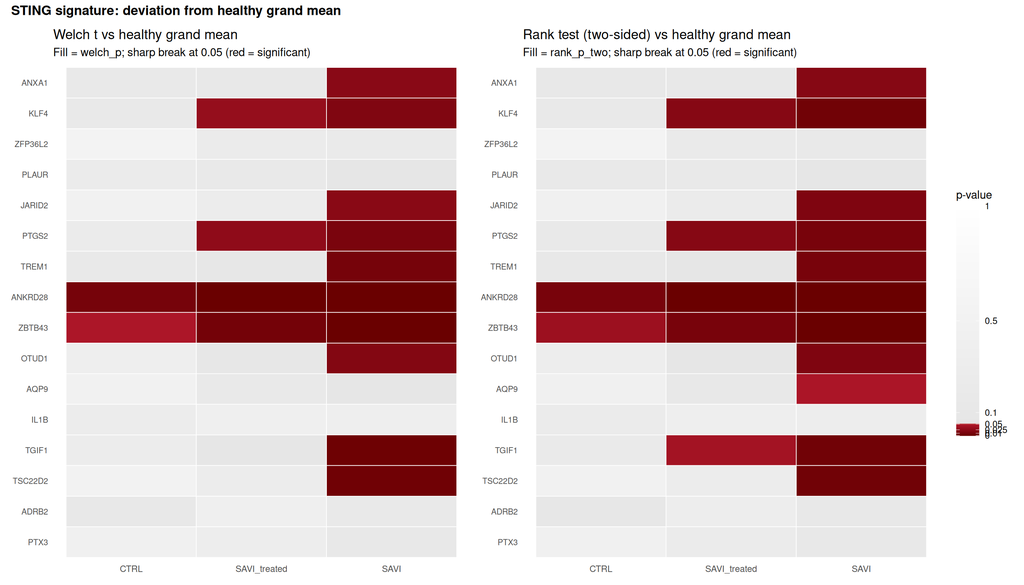

```r
gene_mu_order <- gene_mu_by_cohort |>
  dplyr::filter(.data$Category == "SAVI") |>
  dplyr::arrange(dplyr::desc(.data$cohort_log_mu)) |>
  dplyr::pull(.data$gene)

mu_heat_df <- gene_mu_by_cohort |>
  dplyr::mutate(
    Category = factor(.data$Category, levels = cohort_levels_mu),
    gene = factor(.data$gene, levels = rev(gene_mu_order))
  )

mu_p_heat_scale <- ggplot2::scale_fill_gradientn(
  colours = c("#6a0000", "#b2182b", "#e6e6e6", "#ffffff"),
  values = c(0, 0.05, 0.051, 1),
  limits = c(0, 1),
  oob = scales::squish,
  breaks = c(0, 0.01, 0.025, 0.05, 0.1, 0.5, 1),
  labels = c("0", "0.01", "0.025", "0.05", "0.1", "0.5", "1"),
  guide = ggplot2::guide_colorbar(
    title.position = "top",
    barwidth = ggplot2::unit(0.8, "cm"),
    barheight = ggplot2::unit(8, "cm")
  )
)

plot_mu_p_heatmap <- function(p_var, test_label) {
  ggplot2::ggplot(
    mu_heat_df,
    ggplot2::aes(
      x = .data$Category,
      y = .data$gene,
      fill = .data[[p_var]]
    )
  ) +
    ggplot2::geom_tile(colour = "white", linewidth = 0.3) +
    mu_p_heat_scale +
    ggplot2::labs(
      title = test_label,
      subtitle = sprintf(
        "Fill = %s; sharp break at 0.05 (red = significant)",
        p_var
      ),
      fill = "p-value",
      x = NULL,
      y = NULL
    ) +
    ggplot2::theme_minimal(base_size = 11) +
    ggplot2::theme(
      axis.text.y = ggplot2::element_text(size = 8),
      panel.grid = ggplot2::element_blank()
    )
}

p_welch <- plot_mu_p_heatmap(
  "welch_p",
  "Welch t vs healthy grand mean"
)
p_rank_two <- plot_mu_p_heatmap(
  "rank_p_two",
  "Rank test (two-sided) vs healthy grand mean"
)

(p_welch | p_rank_two) +
  patchwork::plot_layout(guides = "collect") +
  patchwork::plot_annotation(
    title = "STING signature: deviation from healthy grand mean",
    theme = ggplot2::theme(
      plot.title = ggplot2::element_text(size = 13, face = "bold")
    )
  )
```

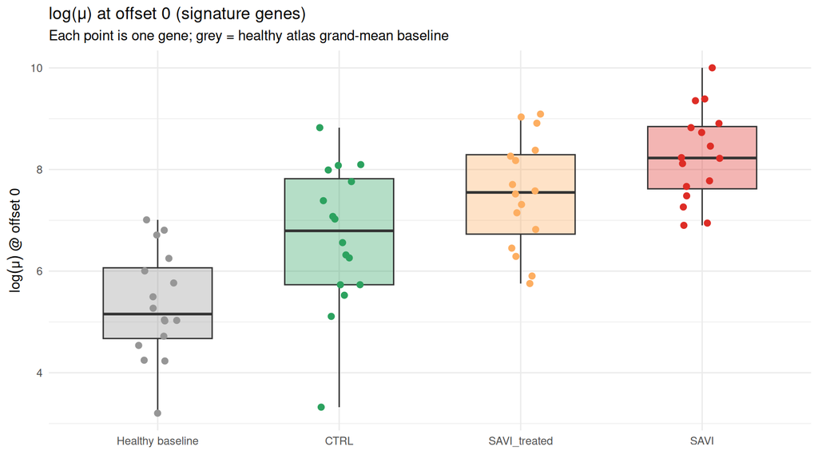

```r
mu_bar_levels <- c("Healthy baseline", cohort_levels_mu)

mu_baseline_bar_df <- gene_mu_by_cohort |>
  dplyr::distinct(.data$gene, .data$baseline_mean_log_mu) |>
  dplyr::transmute(
    gene = .data$gene,
    Category = "Healthy baseline",
    log_mu = .data$baseline_mean_log_mu
  )

mu_bar_df <- gene_mu_by_cohort |>
  dplyr::transmute(
    gene = .data$gene,
    Category = as.character(.data$Category),
    log_mu = .data$cohort_log_mu
  ) |>
  dplyr::bind_rows(mu_baseline_bar_df) |>
  dplyr::mutate(
    Category = factor(.data$Category, levels = mu_bar_levels)
  )

mu_bar_cols <- c(
  "Healthy baseline" = "#969696",
  CTRL = "#2ca25f",
  SAVI_treated = "#fdae61",
  SAVI = "#de2d26"
)

ggplot2::ggplot(
  mu_bar_df,
  ggplot2::aes(
    x = .data$Category,
    y = .data$log_mu,
    fill = .data$Category
  )
) +
  ggplot2::geom_boxplot(outlier.shape = NA, alpha = 0.35, width = 0.6) +
  ggplot2::geom_point(
    ggplot2::aes(colour = .data$Category),
    position = ggplot2::position_jitter(width = 0.12),
    size = 2
  ) +
  ggplot2::scale_fill_manual(values = mu_bar_cols) +
  ggplot2::scale_colour_manual(values = mu_bar_cols) +
  ggplot2::labs(
    title = "log(\u03bc) at offset 0 (signature genes)",
    subtitle = "Each point is one gene; grey = healthy atlas grand-mean baseline",
    x = NULL,
    y = expression(log(mu)~"@ offset 0")
  ) +
  ggplot2::theme_minimal(base_size = 11) +
  ggplot2::theme(legend.position = "none")
```

# STING signature vs paper expectation (grand-mean μ)

**Paper expectation (monocytes):** expression is highest in untreated **SAVI**, intermediate in **SAVI_treated**, and lowest (near atlas healthy) in **CTRL**. Under the grand-mean μ test we look for **SAVI** with the smallest `rank_p_upper` / `welch_p` and the largest `cohort_log_mu`; **CTRL** should stay near the null.

```r
category_cols <- c(
  CTRL = "#2ca25f",
  SAVI_treated = "#756bb1",
  SAVI = "#de2d26"
)

gene_mu_eval <- gene_mu_by_cohort |>
  dplyr::mutate(
    Category = factor(.data$Category, levels = cohort_levels_mu),
    elevated = .data$rank_p_upper < 0.05,
    log2fc_vs_baseline = log2(.data$cohort_mu / .data$baseline_median_mu)
  )

gene_mu_eval |>
  dplyr::select(
    gene, Category, cohort_log_mu, cohort_mu, cohort_se,
    baseline_mean_log_mu, rank_p_upper, welch_p, elevated
  ) |>
  dplyr::arrange(.data$gene, .data$Category)
```

| gene | Category | cohort_log_mu | cohort_mu | cohort_se | baseline_mean_log_mu | rank_p_upper | welch_p | elevated |
| --- | --- | --- | --- | --- | --- | --- | --- | --- |
| ADRB2 | CTRL | 3.322306 | 27.7242 | 0.5661977 | 5.269482 | 0.9625 | 1.215441e-01 | FALSE |
| ADRB2 | SAVI_treated | 6.290005 | 539.1562 | 0.3673164 | 5.269482 | 0.1650 | 3.865152e-01 | FALSE |
| ADRB2 | SAVI | 6.945427 | 1038.3907 | 0.3451214 | 5.269482 | 0.0675 | 1.529548e-01 | FALSE |
| ANKRD28 | CTRL | 7.025052 | 1124.4531 | 0.2826468 | 4.246329 | 0.0050 | 8.958501e-03 | TRUE |
| ANKRD28 | SAVI_treated | 8.379633 | 4357.4080 | 0.3210417 | 4.246329 | 0.0000 | 1.296795e-04 | TRUE |
| ANKRD28 | SAVI | 8.234054 | 3767.0757 | 0.3214332 | 4.246329 | 0.0000 | 2.204829e-04 | TRUE |
| ANXA1 | CTRL | 8.824496 | 6798.7643 | 0.2424478 | 7.009314 | 0.0700 | 1.625006e-01 | FALSE |
| ANXA1 | SAVI_treated | 8.912107 | 7421.2795 | 0.2867112 | 7.009314 | 0.0625 | 1.459796e-01 | FALSE |
| ANXA1 | SAVI | 10.002604 | 22083.8911 | 0.2848217 | 7.009314 | 0.0100 | 2.240065e-02 | TRUE |
| AQP9 | CTRL | 5.731530 | 308.4408 | 0.2461710 | 4.537651 | 0.2175 | 4.799098e-01 | FALSE |

[output cut: 38 more lines]

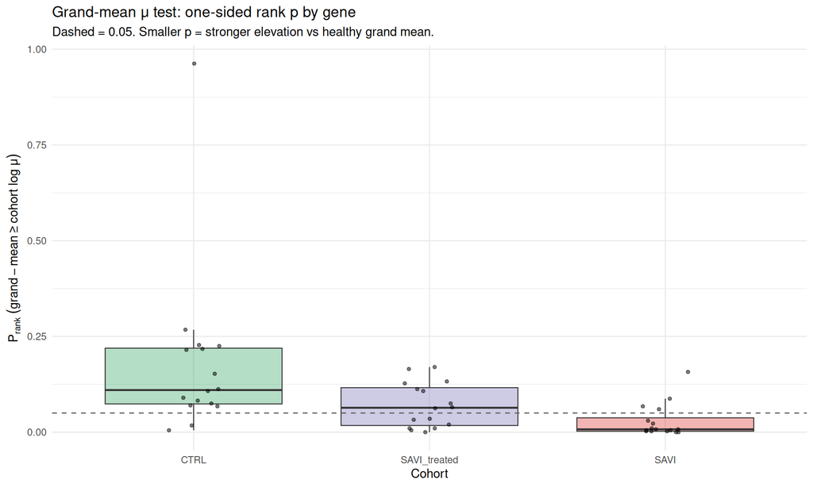

```r
ggplot2::ggplot(
  gene_mu_eval,
  ggplot2::aes(
    x = .data$Category,
    y = .data$rank_p_upper,
    fill = .data$Category
  )
) +
  ggplot2::geom_boxplot(outlier.shape = NA, alpha = 0.35, linewidth = 0.4) +
  ggplot2::geom_jitter(width = 0.12, height = 0, size = 1.1, alpha = 0.5) +
  ggplot2::geom_hline(yintercept = 0.05, linetype = 2, colour = "grey40") +
  ggplot2::scale_fill_manual(values = category_cols, guide = "none") +
  ggplot2::labs(
    x = "Cohort",
    y = expression(P[rank]~(grand - mean >= cohort~log~mu)),
    title = "Grand-mean μ test: one-sided rank p by gene",
    subtitle = "Dashed = 0.05. Smaller p = stronger elevation vs healthy grand mean."
  ) +
  ggplot2::theme_minimal(base_size = 11)
```

# Biomarker quality (atlas falsification on μ)

De Cevins *et al.* selected the 21-gene signature by **within-cohort** comparison (5 SAVI vs 7 study controls). We cross-check each gene against the **Immune Atlas grand-mean μ** null. A credible STING biomarker should show **SAVI elevation** (`rank_p_upper < 0.05`) with **CTRL near null** and, where applicable, **SAVI_treated** between the two.

```r
biomarker_quality <- gene_mu_by_cohort |>
  dplyr::select(
    gene, Category, cohort_log_mu, cohort_mu, rank_p_upper, welch_p,
    baseline_mean_log_mu, baseline_median_mu
  ) |>
  tidyr::pivot_wider(
    names_from = Category,
    values_from = c(cohort_log_mu, cohort_mu, rank_p_upper, welch_p),
    names_sep = "."
  ) |>
  dplyr::mutate(
    savi_lift = .data$cohort_log_mu.SAVI - .data$cohort_log_mu.CTRL,
    treated_lift = .data$cohort_log_mu.SAVI - .data$cohort_log_mu.SAVI_treated,
    ctrl_null_ok = .data$rank_p_upper.CTRL > 0.05,
    savi_elevated = .data$rank_p_upper.SAVI < 0.05,
    biomarker_class = dplyr::case_when(
      .data$savi_elevated & .data$ctrl_null_ok & .data$treated_lift > 0 ~
        "validated",
      .data$savi_elevated & !.data$ctrl_null_ok ~ "savi_up_ctrl_elevated",
      .data$savi_elevated & .data$ctrl_null_ok & .data$treated_lift <= 0 ~
        "savi_up_no_treatment_effect",
      !.data$savi_elevated & .data$cohort_log_mu.CTRL > .data$baseline_mean_log_mu ~
        "falsified_baseline_high",
      !.data$savi_elevated ~ "falsified_no_savi_signal",
      TRUE ~ "ambiguous"
    )
  ) |>
  dplyr::arrange(dplyr::desc(.data$savi_lift))

biomarker_quality |>
  dplyr::select(
    gene, biomarker_class, savi_lift, treated_lift,
    rank_p_upper.SAVI, rank_p_upper.CTRL, welch_p.SAVI
  )
```

| gene | biomarker_class | savi_lift | treated_lift | rank_p_upper.SAVI | rank_p_upper.CTRL | welch_p.SAVI |
| --- | --- | --- | --- | --- | --- | --- |
| ADRB2 | falsified_no_savi_signal | 3.6231218 | 0.6554220 | 0.0675 | 0.9625 | 1.529548e-01 |
| PTGS2 | validated | 2.4103694 | 0.5518261 | 0.0050 | 0.0900 | 1.136419e-02 |
| AQP9 | validated | 2.0458436 | 0.9571056 | 0.0225 | 0.2175 | 5.585076e-02 |
| OTUD1 | validated | 1.8573157 | 0.8060670 | 0.0075 | 0.1525 | 1.784681e-02 |
| PTX3 | falsified_baseline_high | 1.7920363 | 1.1455497 | 0.0600 | 0.2250 | 1.417295e-01 |
| TGIF1 | validated | 1.7495150 | 1.0291006 | 0.0025 | 0.1075 | 2.618570e-03 |
| TSC22D2 | validated | 1.7371694 | 1.3582740 | 0.0025 | 0.2275 | 4.277376e-03 |
| ZBTB43 | savi_up_ctrl_elevated | 1.6592727 | 1.0719599 | 0.0000 | 0.0175 | 5.366656e-05 |
| ZFP36L2 | falsified_baseline_high | 1.5922189 | 0.2631122 | 0.0875 | 0.2675 | 2.015735e-01 |
| JARID2 | validated | 1.4382457 | 1.1201666 | 0.0075 | 0.2150 | 2.220985e-02 |

[output cut: 6 more lines]

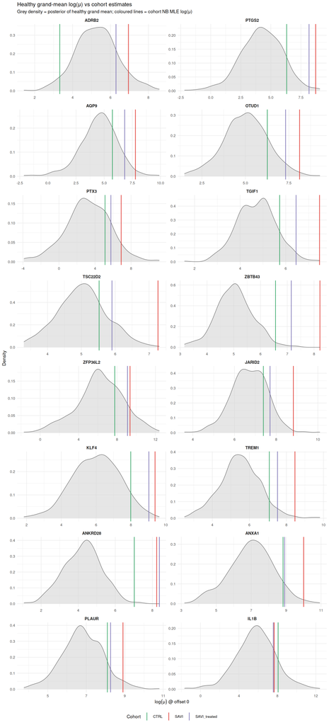

```r
gene_order <- biomarker_quality$gene

biomarker_mu_points <- gene_mu_by_cohort |>
  dplyr::mutate(
    gene = factor(.data$gene, levels = gene_order),
    Category = factor(.data$Category, levels = cohort_levels_mu)
  )

ggplot2::ggplot() +
  ggplot2::geom_density(
    data = gene_mu_baseline_long |>
      dplyr::mutate(gene = factor(.data$gene, levels = gene_order)),
    ggplot2::aes(x = .data$log_mu),
    fill = "grey82",
    colour = "grey35",
    alpha = 0.55,
    linewidth = 0.35
  ) +
  ggplot2::geom_vline(
    data = gene_mu_by_cohort |>
      dplyr::mutate(gene = factor(.data$gene, levels = gene_order)),
    ggplot2::aes(
      xintercept = .data$cohort_log_mu,
      colour = .data$Category
    ),
    linewidth = 0.7,
    alpha = 0.85
  ) +
  ggplot2::scale_colour_manual(values = category_cols) +
  ggplot2::facet_wrap(~ gene, ncol = 2, scales = "free") +
  ggplot2::labs(
    title = "Healthy grand-mean log(\u03bc) vs cohort estimates",
    subtitle = "Grey density = posterior of healthy grand mean; coloured lines = cohort NB MLE log(\u03bc)",
    x = expression(log(mu)~"@ offset 0"),
    y = "Density",
    colour = "Cohort"
  ) +
  ggplot2::theme_minimal(base_size = 10) +
  ggplot2::theme(
    strip.text = ggplot2::element_text(size = 9, face = "bold"),
    legend.position = "bottom"
  )
```

# Case studies on μ (IL1B, TSC22D2, ADRB2)

Three illustrative genes from the signature panel. **`gene_mu_by_cohort`** holds the full results; below we show the grand-mean density with cohort **log μ** markers.

```r
plot_mu_case_study <- function(gene_sym) {
  pts <- gene_mu_by_cohort |>
    dplyr::filter(.data$gene == .env$gene_sym) |>
    dplyr::mutate(Category = factor(.data$Category, levels = cohort_levels_mu))

  base <- gene_mu_baseline_long |>
    dplyr::filter(.data$gene == .env$gene_sym)

  if (!nrow(pts) || !nrow(base)) {
    stop("No mu results for gene ", gene_sym)
  }

  ggplot2::ggplot() +
    ggplot2::geom_density(
      data = base,
      ggplot2::aes(x = .data$log_mu),
      fill = "grey82",
      colour = "grey35",
      alpha = 0.55
    ) +
    ggplot2::geom_vline(
      data = pts,
      ggplot2::aes(
        xintercept = .data$cohort_log_mu,
        colour = .data$Category
      ),
      linewidth = 1
    ) +
    ggplot2::scale_colour_manual(values = category_cols) +
    ggplot2::labs(
      title = paste0(gene_sym, ": cohort log \u03bc vs healthy grand mean"),
      subtitle = sprintf(
        "SAVI rank p = %.4f | CTRL rank p = %.4f",
        pts$rank_p_upper[pts$Category == "SAVI"],
        pts$rank_p_upper[pts$Category == "CTRL"]
      ),
      x = expression(log(mu)~"@ offset 0"),
      y = "Density",
      colour = "Cohort"
    ) +
    ggplot2::theme_minimal(base_size = 11)
}

case_study_genes <- c("IL1B", "TSC22D2", "ADRB2")
gene_mu_by_cohort |>
  dplyr::filter(.data$gene %in% case_study_genes) |>
  dplyr::mutate(elevated = .data$rank_p_upper < 0.05) |>
  dplyr::select(
    gene, Category, cohort_log_mu, cohort_mu, rank_p_upper, welch_p, elevated
  )
```

| gene | Category | cohort_log_mu | cohort_mu | rank_p_upper | welch_p | elevated |
| --- | --- | --- | --- | --- | --- | --- |
| ADRB2 | CTRL | 3.322306 | 27.7242 | 0.9625 | 0.121544132 | FALSE |
| ADRB2 | SAVI_treated | 6.290005 | 539.1562 | 0.1650 | 0.386515208 | FALSE |
| ADRB2 | SAVI | 6.945427 | 1038.3907 | 0.0675 | 0.152954780 | FALSE |
| IL1B | CTRL | 8.079987 | 3229.1918 | 0.1125 | 0.269134764 | FALSE |
| IL1B | SAVI_treated | 7.579261 | 1957.1821 | 0.1700 | 0.388119364 | FALSE |
| IL1B | SAVI | 7.666366 | 2135.3068 | 0.1575 | 0.365684703 | FALSE |
| TSC22D2 | CTRL | 5.525052 | 250.8993 | 0.2275 | 0.523277897 | FALSE |
| TSC22D2 | SAVI_treated | 5.903947 | 366.4811 | 0.1325 | 0.267732237 | FALSE |
| TSC22D2 | SAVI | 7.262221 | 1425.4188 | 0.0025 | 0.004277376 | TRUE |

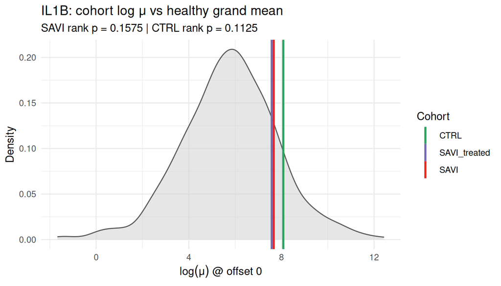

```r
plot_mu_case_study("IL1B")
```

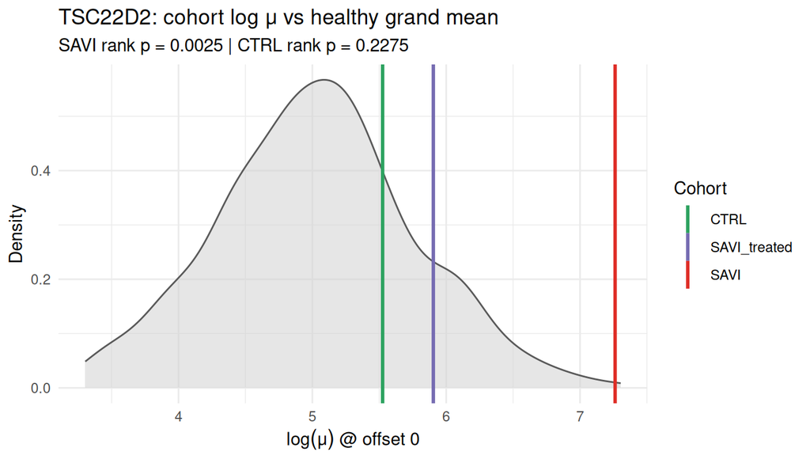

```r
plot_mu_case_study("TSC22D2")
```

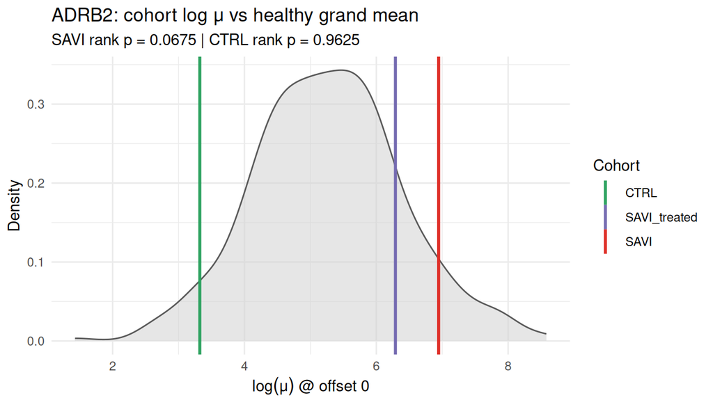

```r
plot_mu_case_study("ADRB2")
```

**IL1B** is often atlas-falsified (CTRL cohort μ near or above the healthy grand mean). **TSC22D2** is a validated contrast (SAVI elevated, CTRL null). **ADRB2** can show SAVI signal driven by a single high-depth donor — the cohort-level μ test aggregates donors via the NB group MLE rather than per-donor tail tests.

# Single-cell expression on UMAP (GEO Seurat object)

Published scRNA-seq object GSE226598 (`prepare_data.R`). We subset **`params$savi_sc_celltype`** (disease-associated monocytes — same population as the pseudobulk merge) and plot signature genes on the embedded UMAP, **`split.by = "Category"`** (`CTRL`, `SAVI`, `SAVI_treated`), using the **`SCT`** assay **`data`** slot (SCTransform–normalized expression from the published object).

```r
read_geo_rds_gz <- function(path) {
  con <- gzcon(gzfile(path))
  on.exit(close(con), add = TRUE)
  readRDS(con)
}

seurat_savi <- read_geo_rds_gz(params$savi_seurat_gz)

if (!"Category" %in% colnames(seurat_savi@meta.data)) {
  stop("`Category` not found in Seurat metadata.")
}

seurat_savi$Category <- factor(
  seurat_savi$Category,
  levels = c("CTRL", "SAVI", "SAVI_treated")
)

seurat_reduction <- function(se) {
  nms <- names(se@reductions)
  hit <- intersect(c("umap", "UMAP", "tsne", "TSNE"), nms)
  if (length(hit)) {
    return(hit[[1]])
  }
  nms[[1]]
}

reduction_use <- seurat_reduction(seurat_savi)

# Subset early so we don't keep the full >2k x 24k object around.
seurat_savi_mono <- seurat_savi |>
  subset(CellType == params$savi_sc_celltype)
# rm(seurat_savi)
# gc(verbose = FALSE)

tibble::tibble(
  n_cells = ncol(seurat_savi_mono),
  reduction = reduction_use,
  categories = paste(levels(seurat_savi_mono$Category), collapse = ", "),
  il1b_present = "IL1B" %in% rownames(seurat_savi_mono),
  adrb2_present = "ADRB2" %in% rownames(seurat_savi_mono)
)
```

| n_cells | reduction | categories | il1b_present | adrb2_present |
| --- | --- | --- | --- | --- |
| 2290 | umap | CTRL, SAVI, SAVI_treated | TRUE | TRUE |

```r
if (ncol(seurat_savi_mono) == 0L) {
  stop(
    "No cells for CellType = '", params$savi_sc_celltype,
    "'. Check `CellType` levels in the Seurat object."
  )
}

seurat_savi_mono$Category <- factor(
  seurat_savi_mono$Category,
  levels = c("CTRL", "SAVI", "SAVI_treated")
)

tibble::tibble(
  cell_type = params$savi_sc_celltype,
  n_cells = ncol(seurat_savi_mono)
)
```

| cell_type | n_cells |
| --- | --- |
| 17. Disease-associated monocytes | 2290 |

```r
table(seurat_savi_mono$Category, useNA = "ifany")
```

```
        CTRL         SAVI SAVI_treated
         344         1528          418
```

#### *IL1B* on UMAP (all donors, paper scaled)

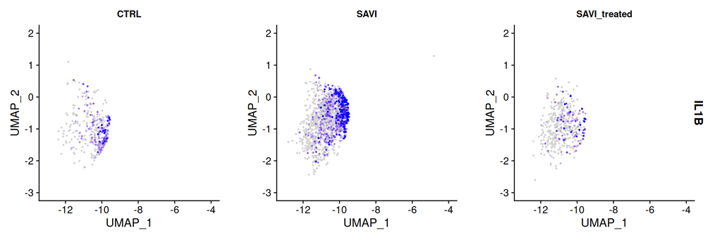

```r
if (!"SCT" %in% SeuratObject::Assays(seurat_savi_mono)) {
  stop(
    "SCT assay not found. Available: ",
    paste(SeuratObject::Assays(seurat_savi_mono), collapse = ", ")
  )
}

if (!"IL1B" %in% rownames(seurat_savi_mono[["SCT"]])) {
  stop("IL1B not found in SCT assay rownames.")
}

Seurat::FeaturePlot(
  seurat_savi_mono,
  features = "IL1B",
  assay = "SCT",
  split.by = "Category",
  reduction = reduction_use,
  slot = "data",
  ncol = 3,
  order = TRUE,
  pt.size = 0.35,
  min.cutoff = "q10",
  max.cutoff = "q90"
) &
  ggplot2::theme(
    plot.title = ggplot2::element_text(size = 11),
    strip.text = ggplot2::element_text(size = 11, face = "bold")
  )
```

#### *IL1B* on UMAP (all donors, TMMwsp scaled)

Same **`split.by = "Category"`** layout as above, but scaling is **TMMwsp on single-cell raw counts** (not pseudobulk multipliers). We run `edgeR::calcNormFactors(..., method = "TMMwsp")` on the **per-cell library sizes** from the `RNA` `counts` slot, derive a per-cell scaling factor, and store the result in a new **`TMMwsp`** assay for `FeaturePlot`.

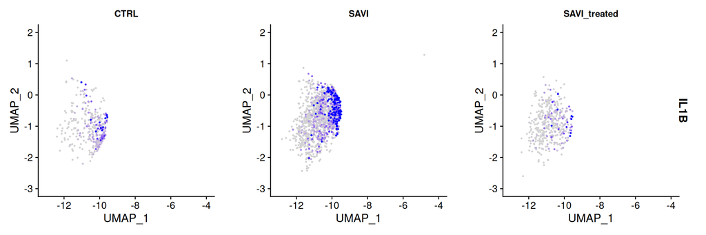

```r
if (!"RNA" %in% SeuratObject::Assays(seurat_savi_mono)) {
  stop(
    "RNA assay not found. Available: ",
    paste(SeuratObject::Assays(seurat_savi_mono), collapse = ", ")
  )
}

if (!"IL1B" %in% rownames(seurat_savi_mono[["RNA"]])) {
  stop("IL1B not found in RNA assay rownames.")
}

rna_counts <- Seurat::GetAssayData(seurat_savi_mono, assay = "RNA", layer = "counts")

lib_size <- Matrix::colSums(rna_counts)

dge <- edgeR::DGEList(counts = rna_counts, lib.size = lib_size)
dge <- edgeR::calcNormFactors(dge, method = "TMMwsp")

eff_lib <- dge$samples$lib.size * dge$samples$norm.factors
scale_factor <- median(eff_lib) / eff_lib

tmmwsp_data <- Matrix::t(Matrix::t(rna_counts) * scale_factor)

seurat_savi_mono[["TMMwsp"]] <- Seurat::CreateAssayObject(data = tmmwsp_data)

Seurat::FeaturePlot(
  seurat_savi_mono,
  features = "IL1B",
  assay = "TMMwsp",
  split.by = "Category",
  reduction = reduction_use,
  slot = "data",
  ncol = 3,
  order = TRUE,
  pt.size = 0.35,
  min.cutoff = "q10",
  max.cutoff = "q90"
) &
  ggplot2::theme(
    plot.title = ggplot2::element_text(size = 11),
    strip.text = ggplot2::element_text(size = 11, face = "bold")
  )
```

The panel above uses **all** disease-associated monocytes per **`Category`** (cell counts differ across arms). Below we **downsample to a balanced number of cells per `Category`** (random sample of size `min_n` within each arm, `set.seed(42)`) so UMAP colour density is not driven by unequal *n*.

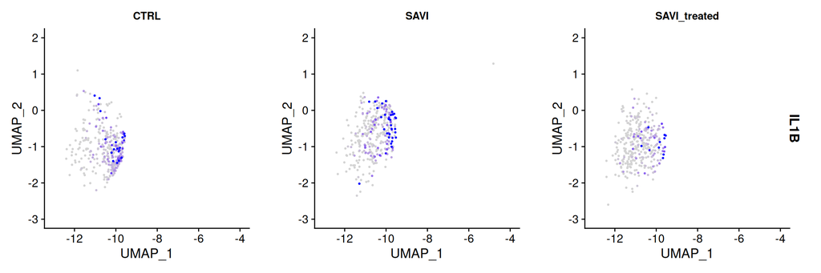

```r
set.seed(42L)
cells_per_cat <- split(
  colnames(seurat_savi_mono),
  seurat_savi_mono$Category
)
min_n <- min(vapply(cells_per_cat, length, integer(1)))
balanced_cells <- unlist(
  lapply(cells_per_cat, function(cc) sample(cc, min_n)),
  use.names = FALSE
)
seurat_balanced <- subset(seurat_savi_mono, cells = balanced_cells)

Seurat::FeaturePlot(
  seurat_balanced,
  features = "IL1B",
  assay = "TMMwsp",
  split.by = "Category",
  reduction = reduction_use,
  slot = "data",
  ncol = 3,
  order = TRUE,
  pt.size = 0.35,
  min.cutoff = "q10",
  max.cutoff = "q90"
) &
  ggplot2::theme(
    plot.title = ggplot2::element_text(size = 11),
    strip.text = ggplot2::element_text(size = 11, face = "bold")
  )
```

Panel titles are **`Category`**. The **paper-scaled** panel above uses **SCT**; these two panels use **TMMwsp** on single-cell `RNA` counts (`edgeR::calcNormFactors`), first with all cells then with balanced *n* per arm.

#### *ADRB2* on UMAP (all donors)

Same layout as *IL1B*: disease-associated monocytes, SCT **`data`**, **`split.by = "Category"`**. Compare the **SAVI** column to **CTRL** and **SAVI_treated** — cells from all donors in each arm are pooled on the UMAP.

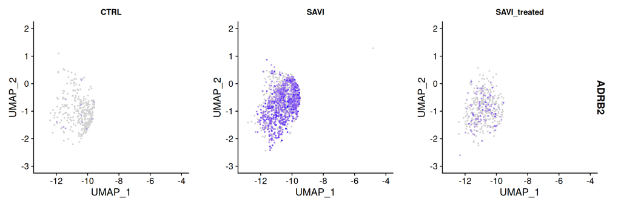

```r
if (!"ADRB2" %in% rownames(seurat_savi_mono[["SCT"]])) {
  stop("ADRB2 not found in SCT assay rownames.")
}

Seurat::FeaturePlot(
  seurat_savi_mono,
  features = "ADRB2",
  assay = "SCT",
  split.by = "Category",
  reduction = reduction_use,
  slot = "data",
  ncol = 3,
  order = TRUE,
  pt.size = 0.35,
  # min.cutoff = "q10",
  # max.cutoff = "q90"
) &
  ggplot2::theme(
    plot.title = ggplot2::element_text(size = 11),
    strip.text = ggplot2::element_text(size = 11, face = "bold")
  )
```

The **SAVI** panel above pools monocytes from all five untreated SAVI donors. Cohort-level **μ** tests classify **`ADRB2`** as **`falsified_no_savi_signal`** (no SAVI elevation vs the healthy grand mean), but single-cell expression can still look elevated if one high-depth donor dominates. **`P6_STING_ht`** is the known outlier in raw pseudobulk counts for this gene.

#### *ADRB2* after removing the high-depth SAVI donor

We repeat the UMAP with **every disease-associated monocyte from `P6_STING_ht` removed**. Assay, cell type, and **`split.by = "Category"`** are unchanged; only that library’s cells are dropped, so the **SAVI** facet reflects the remaining four untreated SAVI donors. If the **SAVI** panel now resembles **CTRL** / **SAVI_treated**, the apparent **`ADRB2`** signal is a **one-donor** artefact at single-cell resolution as well as in pseudobulk.

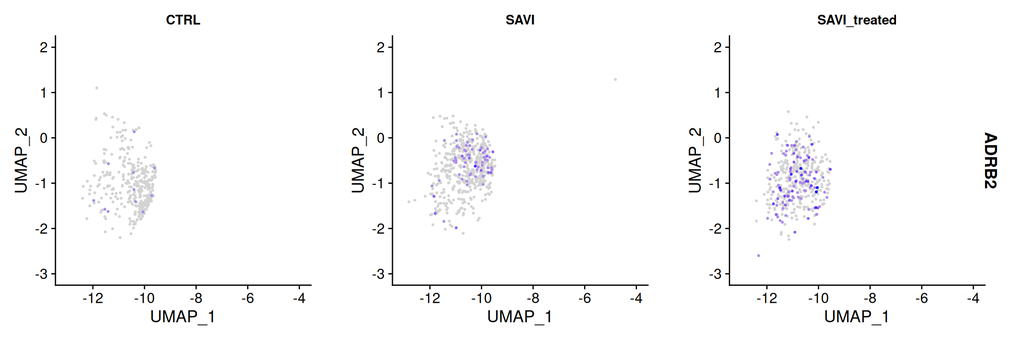

```r
if (!"ADRB2" %in% rownames(seurat_savi_mono[["SCT"]])) {
  stop("ADRB2 not found in SCT assay rownames.")
}

if (!"Sample" %in% colnames(seurat_savi_mono@meta.data)) {
  stop("`Sample` not found in Seurat metadata.")
}

outlier_sample <- "P6_STING_ht"

seurat_savi_mono_no_outlier <- subset(
  seurat_savi_mono,
  subset = Sample != outlier_sample
)

Seurat::FeaturePlot(
  seurat_savi_mono_no_outlier,
  features = "ADRB2",
  assay = "SCT",
  split.by = "Category",
  reduction = reduction_use,
  slot = "data",
  ncol = 3,
  order = TRUE,
  pt.size = 0.35,
  # min.cutoff = "q5",
  # max.cutoff = "q95"
) &
  ggplot2::theme(
    plot.title = ggplot2::element_text(size = 11),
    strip.text = ggplot2::element_text(size = 11, face = "bold")
  )
```

**Read together:** the all-donor and leave-one-out UMAPs complement the cohort **μ** test — is **`ADRB2`** elevated across **SAVI**, or only when **`P6_STING_ht`** is included? A muted **SAVI** panel after exclusion supports the **`falsified_no_savi_signal`** classification from **`biomarker_quality`**.

# Composition analysis vs original SAVI paper

In the original SAVI scRNA-seq paper (de Cevins *et al.* 2023; GSE226598), after QC, integration, clustering, and annotation, the authors report **23 cell populations** in the SAVI dataset and **29 cell populations** in the IFN-beta dataset. They then compare PBMC composition between SAVI and controls (Figure 1E), with p-values from Kruskal-Wallis tests followed by post hoc Dunn’s multiple-comparison testing.

For whole-PBMC composition, the paper reports increased naive CD4 and naive CD8 T cells, decreased effector/memory CD4 and CD8 T-cell compartments, decreased NK cells (especially NK CD56bright), and strong depletion of MAIT and gamma-delta T cells in SAVI. They also report that cell-type proportions did not differ significantly before versus under JAK-inhibitor treatment.

In this notebook, we use those statements as the reference conclusion, then:

1. compute per-sample proportions from GEO **`CellType`** (23 populations),
2. map **`CellType` → Immune Atlas `L3`** labels used by the sccomp composition model,
3. compare observed proportions to **universal (marginalised)** healthy **`predict_res`** draws (pooled over sex, age decade, and other NA covariates; **`tissue_groups = blood`**, **`disease = Normal`** only),
4. summarise trends in **`CTRL`**, **`SAVI`**, and **`SAVI_treated`** against the paper’s Figure 1E conclusions.

```r
paper_composition_summary <- tibble::tribble(
  ~topic, ~paper_finding,
  "Dataset size after integration", "23 populations (SAVI dataset) and 29 populations (IFN-beta dataset).",
  "Naive T-cell compartments", "Naive CD4 and naive CD8 T-cell proportions are increased in SAVI.",
  "Effector/memory T-cell compartments", "Effector/memory CD4 and CD8 compartments are decreased in SAVI.",
  "Innate-like / cytotoxic compartments", "NK cells (notably NK CD56bright), MAIT cells, and gamma-delta T cells are reduced in SAVI.",
  "Treatment comparison", "No significant composition differences were observed before versus under JAK inhibitor treatment.",
  "Statistics in Figure 1E", "Kruskal-Wallis tests with post hoc Dunn's multiple comparisons."
)

paper_composition_summary
```

| topic | paper_finding |
| --- | --- |
| Dataset size after integration | 23 populations (SAVI dataset) and 29 populations (IFN-beta dataset). |
| Naive T-cell compartments | Naive CD4 and naive CD8 T-cell proportions are increased in SAVI. |
| Effector/memory T-cell compartments | Effector/memory CD4 and CD8 compartments are decreased in SAVI. |
| Innate-like / cytotoxic compartments | NK cells (notably NK CD56bright), MAIT cells, and gamma-delta T cells are reduced in SAVI. |
| Treatment comparison | No significant composition differences were observed before versus under JAK inhibitor treatment. |
| Statistics in Figure 1E | Kruskal-Wallis tests with post hoc Dunn's multiple comparisons. |

```r
paper_ct_alignment <- tibble::tribble(
  ~paper_compartment, ~direction_in_savi, ~celltype_labels_in_this_object, ~mapping_note,
  "Naive CD4 T", "increased", "0. Naive CD4", "Directly aligned.",
  "Effector/memory CD4", "decreased", "3. CM CD4; 4. EM CD4; 8. TE CD4; 9. Tregs and TE CD4", "Approximate effector/memory CD4 pool from available labels.",
  "Naive CD8 T", "increased", "2. Naive CD8", "Directly aligned.",
  "Effector/memory CD8", "decreased", "14. CM CD8; 15. EM CD8; 7. TE CD8", "Approximate effector/memory CD8 pool from available labels.",
  "NK (especially CD56bright)", "decreased", "10. NK; 26. NK CD56bright", "CD56bright is explicitly available.",
  "MAIT", "strongly decreased", "22. MAIT", "Directly aligned.",
  "gamma-delta T", "strongly decreased", "16. gd T cells", "Directly aligned.",
  "Myeloid context (not primary Figure 1E claim)", "context", "5. Classical monocytes; 12. Non-classical monocytes; 17. Disease-associated monocytes; 20. cDCs; 27. pDCs", "Contextual comparison only.",
  "B-cell context (not primary Figure 1E claim)", "context", "1. Naive B; 6. Transitionnal B; 13. Memory B; 11. CD3+ B cells; 25. Plasmablasts", "Contextual comparison only."
)

paper_ct_alignment
```

| paper_compartment | direction_in_savi | celltype_labels_in_this_object | mapping_note |
| --- | --- | --- | --- |
| Naive CD4 T | increased | 0. Naive CD4 | Directly aligned. |
| Effector/memory CD4 | decreased | 3. CM CD4; 4. EM CD4; 8. TE CD4; 9. Tregs and TE CD4 | Approximate effector/memory CD4 pool from available labels. |
| Naive CD8 T | increased | 2. Naive CD8 | Directly aligned. |
| Effector/memory CD8 | decreased | 14. CM CD8; 15. EM CD8; 7. TE CD8 | Approximate effector/memory CD8 pool from available labels. |
| NK (especially CD56bright) | decreased | 10. NK; 26. NK CD56bright | CD56bright is explicitly available. |
| MAIT | strongly decreased | 22. MAIT | Directly aligned. |
| gamma-delta T | strongly decreased | 16. gd T cells | Directly aligned. |
| Myeloid context (not primary Figure 1E claim) | context | 5. Classical monocytes; 12. Non-classical monocytes; 17. Disease-associated monocytes; 20. cDCs; 27. pDCs | Contextual comparison only. |
| B-cell context (not primary Figure 1E claim) | context | 1. Naive B; 6. Transitionnal B; 13. Memory B; 11. CD3+ B cells; 25. Plasmablasts | Contextual comparison only. |

```r
if (!exists("read_geo_rds_gz", mode = "function")) {
  read_geo_rds_gz <- function(path) {
    con <- gzcon(gzfile(path))
    on.exit(close(con), add = TRUE)
    readRDS(con)
  }
}

if (!exists("seurat_savi", inherits = FALSE)) {
  seurat_savi <- read_geo_rds_gz(params$savi_seurat_gz)
}

if (!"Category" %in% colnames(seurat_savi@meta.data)) {
  stop("`Category` not found in Seurat metadata.")
}
if (!"CellType" %in% colnames(seurat_savi@meta.data)) {
  stop("`CellType` not found in Seurat metadata.")
}

seurat_savi$Category <- factor(
  seurat_savi$Category,
  levels = c("CTRL", "SAVI", "SAVI_treated")
)

# GEO sample metadata (same table as pseudobulk join above).
geo_tbl_comp <- geo_tbl |>
  dplyr::mutate(
    sex = dplyr::case_when(
      .data$gse_sex == "M" ~ "male",
      .data$gse_sex == "F" ~ "female",
      TRUE ~ NA_character_
    ),
    age_decade = as.character(ceiling(.data$gse_age_years / 10))
  ) |>
  dplyr::select("Sample", "sex", "age_decade", "gse_age_years")

# Fine-grained CellType -> Immune Atlas L3 (posteriorHCA / sccomp) labels.
celltype_to_l3 <- tibble::tribble(
  ~cell_type, ~L3,
  "0. Naive CD4", "cd4 naive",
  "2. Naive CD8", "cd8 naive",
  "3. CM CD4", "cd4 tcm",
  "4. EM CD4", "cd4 th1 em",
  "8. TE CD4", "cd4 th1 em",
  "9. Tregs and TE CD4", "treg",
  "14. CM CD8", "cd8 tcm",
  "15. EM CD8", "cd8 tem",
  "7. TE CD8", "cd8 tem",
  "10. NK", "nk",
  "26. NK CD56bright", "nk",
  "22. MAIT", "mait",
  "16. gd T cells", "tgd",
  "1. Naive B", "b naive",
  "6. Transitionnal B", "b naive",
  "13. Memory B", "b memory",
  "11. CD3+ B cells", "b memory",
  "5. Classical monocytes", "cd14 mono",
  "12. Non-classical monocytes", "cd16 mono",
  "17. Disease-associated monocytes", "cd14 mono",
  "20. cDCs", "cdc",
  "27. pDCs", "pdc",
  "25. Plasmablasts", "plasma"
)

cell_tbl <- seurat_savi@meta.data |>
  tibble::rownames_to_column("cell_id") |>
  dplyr::transmute(
    sample_id = as.character(.data$Sample),
    Category = as.character(.data$Category),
    cell_type = as.character(.data$CellType)
  ) |>
  dplyr::left_join(celltype_to_l3, by = "cell_type") |>
  dplyr::left_join(geo_tbl_comp, by = c("sample_id" = "Sample"))

example_proportions_celltype <- cell_tbl |>
  dplyr::filter(!is.na(.data$cell_type), nzchar(.data$cell_type)) |>
  dplyr::count(.data$sample_id, .data$cell_type, name = "n_cells") |>
  dplyr::group_by(.data$sample_id) |>
  dplyr::mutate(proportion = .data$n_cells / sum(.data$n_cells)) |>
  dplyr::ungroup() |>
  dplyr::select(.data$sample_id, .data$cell_type, .data$proportion)

# L3-level observed proportions (merge CellType labels that map to the same L3).
example_proportions <- cell_tbl |>
  dplyr::filter(!is.na(.data$L3)) |>
  dplyr::count(.data$sample_id, .data$Category, .data$sex, .data$age_decade, .data$L3, name = "n_cells") |>
  dplyr::group_by(.data$sample_id, .data$Category, .data$sex, .data$age_decade, .data$L3) |>
  dplyr::summarise(proportion = sum(.data$n_cells), .groups = "drop_last") |>
  dplyr::group_by(.data$sample_id) |>
  dplyr::mutate(proportion = .data$proportion / sum(.data$proportion)) |>
  dplyr::ungroup() |>
  dplyr::rename(cell_type = L3) |>
  dplyr::arrange(.data$sample_id, .data$cell_type)

unmapped_celltypes <- cell_tbl |>
  dplyr::filter(is.na(.data$L3)) |>
  dplyr::count(.data$cell_type, sort = TRUE)

tibble::tibble(
  label_column_used = "CellType",
  n_samples = dplyr::n_distinct(example_proportions$sample_id),
  n_cells_total = nrow(cell_tbl),
  n_celltypes_raw = dplyr::n_distinct(example_proportions_celltype$cell_type),
  n_l3_types = dplyr::n_distinct(example_proportions$cell_type),
  n_unmapped_celltypes = nrow(unmapped_celltypes)
)
```

| label_column_used | n_samples | n_cells_total | n_celltypes_raw | n_l3_types | n_unmapped_celltypes |
| --- | --- | --- | --- | --- | --- |
| CellType | 17 | 112060 | 23 | 17 | 0 |

```r
if (nrow(unmapped_celltypes) > 0L) {
  unmapped_celltypes
}
```

### Healthy atlas composition null (`predict_res`)

Posterior draws of blood PBMC composition from the Immune Atlas sccomp model under a **universal** null: **`disease_groups___altered = Normal`**, **`tissue_groups = blood`**, and **`NA`** for **`dataset_id___altered`**, **`sex`**, **`age_decade`**, **`ethnicity_groups_imputed`**, and **`assay_groups___altered`** (sccomp marginalises over those levels). The draw table is saved once to **`params$composition_predict_rds`** (separate RDS from the personalised case study) and trimmed to L3 types present in the SAVI cohort.

```r
if (!requireNamespace("sccomp", quietly = TRUE)) {
  stop("Package `sccomp` is required for composition prediction.")
}

l3_for_comparison <- example_proportions |>
  dplyr::distinct(.data$cell_type) |>
  dplyr::pull(.data$cell_type)

trim_predict_res <- function(x, cell_types) {
  x |>
    dplyr::filter(.data$cell_type %in% cell_types) |>
    dplyr::select(dplyr::any_of(c(
      "sample_id",
      "age_decade",
      "sex",
      "cell_type",
      "proportion",
      ".draw"
    )))
}

if (file.exists(params$composition_predict_rds)) {
  predict_res <- readRDS(params$composition_predict_rds)
} else {
  sccomp_est <- readRDS(params$sccomp_estimates_rds)

  sample_metadata <- tibble::tibble(
    assay_groups___altered = NA_character_,
    disease_groups___altered = "Normal",
    tissue_groups = "blood",
    ethnicity_groups_imputed = NA_character_,
    age_decade = NA_character_,
    sex = NA_character_,
    dataset_id___altered = NA_character_,
    sample_id = "universal_baseline"
  )

  predict_res <- sccomp_est |>
    sccomp::sccomp_predict(
      formula_composition = NULL,
      new_data = sample_metadata,
      summary_instead_of_draws = FALSE
    ) |>
    dplyr::rename(cell_type = L3) |>
    trim_predict_res(l3_for_comparison)

  predict_dir <- dirname(params$composition_predict_rds)
  if (!dir.exists(predict_dir)) {
    dir.create(predict_dir, recursive = TRUE, showWarnings = FALSE)
  }
  saveRDS(predict_res, params$composition_predict_rds, compress = "xz")
}

predict_res <- trim_predict_res(predict_res, l3_for_comparison)

predict_res |>
  dplyr::distinct(.data$cell_type) |>
  dplyr::count(name = "n_cell_types")
```

| n_cell_types |
| --- |
| 17 |

### Compare observed SAVI proportions to healthy predictive draws

For each donor we compare against the **pooled** universal **`predict_res`** draws (same draws for every donor × L3 type), then compute empirical tail probabilities (same logic as `posteriorHCA::composition_posterior_test()`).

```r
composition_vs_healthy <- example_proportions |>
  dplyr::rename(
    sample_id_observed = sample_id,
    cell_type_observed = cell_type,
    proportion_observed = proportion
  ) |>
  dplyr::inner_join(
    predict_res |>
      dplyr::select(cell_type, proportion_sampled = proportion, .draw),
    by = c("cell_type_observed" = "cell_type"),
    relationship = "many-to-many"
  ) |>
  dplyr::group_by(.data$sample_id_observed, .data$Category, .data$cell_type_observed) |>
  dplyr::summarise(
    proportion_observed = dplyr::first(.data$proportion_observed),
    healthy_median = stats::median(.data$proportion_sampled),
    healthy_mean = mean(.data$proportion_sampled),
    healthy_hpd_lo = stats::quantile(.data$proportion_sampled, 0.025),
    healthy_hpd_hi = stats::quantile(.data$proportion_sampled, 0.975),
    # Same tail convention as gene-level μ rank tests: P(draw >= obs), not P(obs > draw).
    p_above_healthy = mean(.data$proportion_sampled >= .data$proportion_observed),
    p_below_healthy = mean(.data$proportion_sampled <= .data$proportion_observed),
    empirical_confidence = 2 * pmin(.data$p_above_healthy, .data$p_below_healthy),
    direction = dplyr::case_when(
      .data$p_above_healthy < 0.025 ~ "higher_than_healthy",
      .data$p_below_healthy < 0.025 ~ "lower_than_healthy",
      TRUE ~ "consistent_with_healthy"
    ),
    .groups = "drop"
  )

composition_vs_healthy |>
  dplyr::arrange(.data$Category, .data$cell_type_observed, .data$sample_id_observed) |>
  dplyr::slice_head(n = 12)
```

| sample_id_observed | Category | cell_type_observed | proportion_observed | healthy_median | healthy_mean | healthy_hpd_lo | healthy_hpd_hi | p_above_healthy | p_below_healthy | empirical_confidence | direction |
| --- | --- | --- | --- | --- | --- | --- | --- | --- | --- | --- | --- |
| C1 | CTRL | b memory | 0.03109734 | 0.04074257 | 0.04491080 | 0.01713071 | 0.09347771 | 0.724 | 0.276 | 0.552 | consistent_with_healthy |
| C10 | CTRL | b memory | 0.02790052 | 0.04074257 | 0.04491080 | 0.01713071 | 0.09347771 | 0.792 | 0.208 | 0.416 | consistent_with_healthy |
| C11 | CTRL | b memory | 0.02373307 | 0.04074257 | 0.04491080 | 0.01713071 | 0.09347771 | 0.886 | 0.114 | 0.228 | consistent_with_healthy |
| C2 | CTRL | b memory | 0.06764499 | 0.04074257 | 0.04491080 | 0.01713071 | 0.09347771 | 0.126 | 0.874 | 0.252 | consistent_with_healthy |
| C7 | CTRL | b memory | 0.10581456 | 0.04074257 | 0.04491080 | 0.01713071 | 0.09347771 | 0.012 | 0.988 | 0.024 | higher_than_healthy |
| C8_aunt_P1_STING | CTRL | b memory | 0.03123687 | 0.04074257 | 0.04491080 | 0.01713071 | 0.09347771 | 0.718 | 0.282 | 0.564 | consistent_with_healthy |
| C9_mother_P1_STING | CTRL | b memory | 0.03290415 | 0.04074257 | 0.04491080 | 0.01713071 | 0.09347771 | 0.674 | 0.326 | 0.652 | consistent_with_healthy |
| C1 | CTRL | b naive | 0.07172644 | 0.06150109 | 0.06758058 | 0.02450001 | 0.14739281 | 0.350 | 0.650 | 0.700 | consistent_with_healthy |
| C10 | CTRL | b naive | 0.10289105 | 0.06150109 | 0.06758058 | 0.02450001 | 0.14739281 | 0.122 | 0.878 | 0.244 | consistent_with_healthy |
| C11 | CTRL | b naive | 0.07441016 | 0.06150109 | 0.06758058 | 0.02450001 | 0.14739281 | 0.316 | 0.684 | 0.632 | consistent_with_healthy |

[output cut: 2 more lines]

### Paper compartments: trend by `Category` and comparison to published direction

We aggregate mapped L3 labels into the Figure 1E compartments from the paper, then summarise mean proportion per **`Category`** and compare the SAVI–CTRL direction to the published expectation.

```r
paper_compartment_l3 <- tibble::tribble(
  ~paper_compartment, ~direction_in_savi, ~cell_type,
  "Naive CD4 T", "increased", "cd4 naive",
  "Effector/memory CD4", "decreased", "cd4 tcm",
  "Effector/memory CD4", "decreased", "cd4 th1 em",
  "Effector/memory CD4", "decreased", "cd4 th17 em",
  "Effector/memory CD4", "decreased", "cd4 th2 em",
  "Effector/memory CD4", "decreased", "cd4 fh em",
  "Effector/memory CD4", "decreased", "cd4 th1/th17 em",
  "Effector/memory CD4", "decreased", "treg",
  "Naive CD8 T", "increased", "cd8 naive",
  "Effector/memory CD8", "decreased", "cd8 tcm",
  "Effector/memory CD8", "decreased", "cd8 tem",
  "NK", "decreased", "nk",
  "MAIT", "strongly decreased", "mait",
  "gamma-delta T", "strongly decreased", "tgd"
)

paper_compartment_levels <- paper_compartment_l3 |>
  dplyr::distinct(.data$paper_compartment) |>
  dplyr::pull(.data$paper_compartment)

composition_paper_per_donor <- composition_vs_healthy |>
  dplyr::inner_join(paper_compartment_l3, by = c("cell_type_observed" = "cell_type")) |>
  dplyr::group_by(
    .data$sample_id_observed,
    .data$Category,
    .data$paper_compartment,
    .data$direction_in_savi
  ) |>
  dplyr::summarise(
    proportion_observed = sum(.data$proportion_observed),
    healthy_median = sum(.data$healthy_median),
    direction = dplyr::if_else(
      any(.data$direction == "higher_than_healthy"),
      "higher_than_healthy",
      dplyr::if_else(
        any(.data$direction == "lower_than_healthy"),
        "lower_than_healthy",
        "consistent_with_healthy"
      )
    ),
    .groups = "drop"
  )

# Donors with zero cells in a compartment are absent from counts; fill with 0 so
# category means (and CTRL dots) include all donors in each Category.
all_donors_comp <- example_proportions |>
  dplyr::distinct(.data$sample_id, .data$Category) |>
  dplyr::rename(sample_id_observed = sample_id)

compartment_meta <- paper_compartment_l3 |>
  dplyr::distinct(.data$paper_compartment, .data$direction_in_savi)

composition_paper_long <- tidyr::crossing(all_donors_comp, compartment_meta) |>
  dplyr::left_join(
    composition_paper_per_donor,
    by = c("sample_id_observed", "Category", "paper_compartment", "direction_in_savi")
  ) |>
  dplyr::mutate(
    paper_compartment = factor(.data$paper_compartment, levels = paper_compartment_levels),
    proportion_observed = dplyr::coalesce(.data$proportion_observed, 0),
    healthy_median = dplyr::coalesce(.data$healthy_median, 0),
    direction = dplyr::coalesce(.data$direction, "consistent_with_healthy")
  )

composition_paper_summary <- composition_paper_long |>
  dplyr::group_by(.data$paper_compartment, .data$direction_in_savi, .data$Category) |>
  dplyr::summarise(
    n_samples = dplyr::n(),
    mean_prop = mean(.data$proportion_observed),
    median_prop = stats::median(.data$proportion_observed),
    mean_healthy_median = mean(.data$healthy_median),
    .groups = "drop"
  ) |>
  tidyr::pivot_wider(
    names_from = Category,
    values_from = c(mean_prop, median_prop, n_samples),
    names_sep = "__"
  ) |>
  dplyr::mutate(
    delta_savi_minus_ctrl = .data$mean_prop__SAVI - .data$mean_prop__CTRL,
    delta_treated_minus_ctrl = .data$mean_prop__SAVI_treated - .data$mean_prop__CTRL,
    matches_paper_savi = dplyr::case_when(
      .data$direction_in_savi == "increased" ~ .data$delta_savi_minus_ctrl > 0,
      .data$direction_in_savi %in% c("decreased", "strongly decreased") ~ .data$delta_savi_minus_ctrl < 0,
      TRUE ~ NA
    ),
    matches_paper_treated = dplyr::case_when(
      .data$direction_in_savi == "increased" ~ .data$delta_treated_minus_ctrl > 0,
      .data$direction_in_savi %in% c("decreased", "strongly decreased") ~ .data$delta_treated_minus_ctrl < 0,
      TRUE ~ NA
    )
  ) |>
  dplyr::arrange(.data$paper_compartment)

composition_paper_summary
```

| paper_compartment | direction_in_savi | mean_healthy_median | mean_prop__CTRL | mean_prop__SAVI | mean_prop__SAVI_treated | median_prop__CTRL | median_prop__SAVI | median_prop__SAVI_treated | n_samples__CTRL | n_samples__SAVI | n_samples__SAVI_treated | delta_savi_minus_ctrl | delta_treated_minus_ctrl | matches_paper_savi | matches_paper_treated |
| --- | --- | --- | --- | --- | --- | --- | --- | --- | --- | --- | --- | --- | --- | --- | --- |
| Naive CD4 T | increased | 0.149563830 | 0.13454214 | 0.1178313751 | 0.1335763938 | 0.12272590 | 0.1395888082 | 0.1468498342 | 7 | 5 | 5 | -0.01671077 | -0.0009657479 | FALSE | FALSE |
| Effector/memory CD4 | decreased | 0.204874953 | 0.27312712 | 0.2178529260 | 0.1714490033 | 0.23690823 | 0.1791621580 | 0.1642066421 | 7 | 5 | 5 | -0.05527420 | -0.1016781210 | TRUE | TRUE |
| Naive CD8 T | increased | 0.087188760 | 0.06582260 | 0.1517273578 | 0.1165874487 | 0.07257121 | 0.1667425968 | 0.1310313286 | 7 | 5 | 5 | 0.08590476 | 0.0507648516 | TRUE | TRUE |
| Effector/memory CD8 | decreased | 0.183187398 | 0.13104561 | 0.0547403692 | 0.0574797344 | 0.13304481 | 0.0624145786 | 0.0430379747 | 7 | 5 | 5 | -0.07630524 | -0.0735658760 | TRUE | TRUE |
| NK | decreased | 0.119933600 | 0.05431243 | 0.0238811185 | 0.0277958863 | 0.04456094 | 0.0205372887 | 0.0180009474 | 7 | 5 | 5 | -0.03043131 | -0.0265165420 | TRUE | TRUE |
| MAIT | strongly decreased | 0.007090952 | 0.01746032 | NA | NA | 0.01431814 | NA | NA | 7 | NA | NA | NA | NA | NA | NA |
| MAIT | strongly decreased | 0.004254571 | NA | 0.0008085549 | 0.0002977762 | NA | 0.0002074474 | 0.0002462751 | NA | 5 | 5 | NA | NA | NA | NA |
| gamma-delta T | strongly decreased | 0.020771078 | 0.03445293 | 0.0181885750 | 0.0109481129 | 0.03407465 | 0.0166320166 | 0.0108953103 | 7 | 5 | 5 | -0.01626435 | -0.0235048155 | TRUE | TRUE |

### Cohort-level composition vs healthy baseline (sccomp group-means fit)

Per-donor tail tests above treat each library separately. For parity with the **gene μ workflow**, we also fit a **cohort-aggregated** compositional model on the SAVI study proportions and compare each cohort’s **central compartment proportion** to the universal healthy **`predict_res`** null.

#### sccomp `multi_beta_binomial` — linear predictor and link

The atlas sccomp model (same family as we refit on SAVI) uses a **compositional linear predictor** plus a separate **precision** sub-model:

| Symbol | Role |
| --- | --- |
| $\boldsymbol\eta_n \in \mathbb{R}^M$ | Linear predictor for sample $n$ (one value per cell type $m$) |
| $\boldsymbol\pi_n = \mathrm{softmax}(\boldsymbol\eta_n)$ | **Mean composition** (location); $\sum_m \pi_{n,m} = 1$ |
| $\phi_n = \exp(\mathbf{x}^{(v)\top}_n \boldsymbol\alpha)$ | **Precision** (overdispersion; not the mean) |

**Composition mean (Stan):** for design matrix $\mathbf{X}$ and coefficient matrix $\boldsymbol\beta$ ($C \times M$, sum-to-zero across cell types per column for identifiability),

$$\boldsymbol\eta_n = \mathbf{x}_n^\top \boldsymbol\beta \;+\; \text{(random effects)}, \qquad
\boldsymbol\pi_n = \mathrm{softmax}(\boldsymbol\eta_n).$$

**Likelihood** (`is_proportion = 1`): each observed proportion $y_{n,m}$ is treated as a **Beta** draw with mean $\pi_{n,m}$ and precision $\phi_n$:

$$y_{n,m} \sim \mathrm{Beta}\bigl(\pi_{n,m}\,\phi_n,\; (1-\pi_{n,m})\,\phi_n\bigr).$$

(With count input, the same $(\boldsymbol\pi_n, \phi_n)$ parameterise a **beta-binomial** instead.)

**Cohort fit:** `formula_composition = ~ 0 + Category` gives one sum-to-zero coefficient vector $\boldsymbol\beta_k$ per arm (**CTRL**, **SAVI_treated**, **SAVI**). All samples in cohort $k$ share $\boldsymbol\pi = \mathrm{softmax}(\boldsymbol\beta_k)$ — the direct analogue of edgeR `~ 0 + group` for log(μ).

**Baseline null:** universal `sccomp_predict` on the **atlas** fit (NA covariates marginalised). We summarise **paper-compartment** mass per draw and treat the posterior SD as the healthy SE (same logic as `sd(grand_mean_draws)` for genes).

**Tests:** for each cohort × paper compartment — **rank** $p = P(\text{baseline draw} \ge \text{cohort estimate})$ (primary; non-parametric) and **Welch** $t$ on the proportion scale using cohort posterior SD vs baseline draw SD (parametric cross-check). Welch is approximate on $[0,1]$ but useful when both SDs are small; rank $p$ remains the robust primary.

```r
if (!requireNamespace("sccomp", quietly = TRUE)) {
  stop("Package `sccomp` is required for cohort composition modelling.")
}

cohort_levels_comp <- c("CTRL", "SAVI_treated", "SAVI")

sample_category_comp <- example_proportions |>
  dplyr::distinct(.data$sample_id, .data$Category)

sccomp_input <- example_proportions |>
  dplyr::filter(.data$cell_type %in% l3_for_comparison) |>
  dplyr::distinct(.data$sample_id, .data$cell_type, .data$proportion) |>
  tidyr::complete(
    .data$sample_id,
    cell_type = l3_for_comparison,
    fill = list(proportion = 0)
  ) |>
  dplyr::left_join(sample_category_comp, by = "sample_id") |>
  dplyr::mutate(
    Category = factor(.data$Category, levels = cohort_levels_comp),
    proportion = pmax(.data$proportion, 0)
  ) |>
  dplyr::group_by(.data$sample_id) |>
  dplyr::mutate(
    proportion = .data$proportion / sum(.data$proportion)
  ) |>
  dplyr::ungroup()


if (file.exists(params$savi_sccomp_cohort_fit_rds) && !isTRUE(params$run_sccomp_savi_fit)) {
  sccomp_cohort_fit <- readRDS(params$savi_sccomp_cohort_fit_rds)
} else {
  sccomp_cohort_fit <- sccomp::sccomp_estimate(
    sccomp_input,
    formula_composition = ~ 0 + Category,
    formula_variability = ~ 1,
    sample = "sample_id",
    cell_group = "cell_type",
    abundance = "proportion",
    cores = parallel::detectCores(),
    verbose = TRUE
  )
  fit_dir <- dirname(params$savi_sccomp_cohort_fit_rds)
  if (!dir.exists(fit_dir)) {
    dir.create(fit_dir, recursive = TRUE, showWarnings = FALSE)
  }
  saveRDS(sccomp_cohort_fit, params$savi_sccomp_cohort_fit_rds, compress = "xz")
}

cell_group_col <- attr(sccomp_cohort_fit, ".cell_group")
cell_group_name <- rlang::as_label(cell_group_col)

cohort_pred_meta <- tibble::tibble(
  Category = factor(cohort_levels_comp, levels = cohort_levels_comp),
  sample_id = paste0("cohort_", cohort_levels_comp)
)

cohort_pred_draws <- sccomp::sccomp_predict(
  sccomp_cohort_fit,
  new_data = cohort_pred_meta,
  summary_instead_of_draws = FALSE
)
```

```
Running standalone generated quantities after 1 MCMC chain, with 1 thread(s) per chain...

Chain 1  Elapsed Time: 0.107 seconds (Generated Quantities)
Chain 1 finished in 0.0 seconds.
```

```r
if (!cell_group_name %in% names(cohort_pred_draws)) {
  stop("Expected cell group column `", cell_group_name, "` in sccomp_predict output.")
}

cohort_pred_draws <- cohort_pred_draws |>
  dplyr::rename(cell_type = !!rlang::sym(cell_group_name))

tibble::tibble(
  n_samples = dplyr::n_distinct(sccomp_input$sample_id),
  n_cell_types = dplyr::n_distinct(sccomp_input$cell_type),
  n_posterior_draws = dplyr::n_distinct(cohort_pred_draws$.draw),
  design = "~ 0 + Category",
  abundance = "proportion"
)
```

| n_samples | n_cell_types | n_posterior_draws | design | abundance |
| --- | --- | --- | --- | --- |
| 17 | 17 | 500 | ~ 0 + Category | proportion |

```r
baseline_compartment_draws <- predict_res |>
  dplyr::inner_join(
    paper_compartment_l3 |>
      dplyr::distinct(.data$paper_compartment, .data$cell_type),
    by = "cell_type"
  ) |>
  dplyr::group_by(.data$paper_compartment, .data$.draw) |>
  dplyr::summarise(
    baseline_comp_prop = sum(.data$proportion),
    .groups = "drop"
  )

baseline_compartment_summary <- baseline_compartment_draws |>
  dplyr::group_by(.data$paper_compartment) |>
  dplyr::summarise(
    baseline_mean = mean(.data$baseline_comp_prop),
    baseline_sd = stats::sd(.data$baseline_comp_prop),
    baseline_median = stats::median(.data$baseline_comp_prop),
    n_grand = dplyr::n(),
    .groups = "drop"
  )

cohort_compartment_draws <- cohort_pred_draws |>
  dplyr::inner_join(
    paper_compartment_l3 |>
      dplyr::distinct(.data$paper_compartment, .data$cell_type),
    by = "cell_type"
  ) |>
  dplyr::group_by(.data$Category, .data$paper_compartment, .data$.draw) |>
  dplyr::summarise(
    cohort_comp_prop = sum(.data$proportion),
    .groups = "drop"
  )

cohort_compartment_summary <- cohort_compartment_draws |>
  dplyr::group_by(.data$Category, .data$paper_compartment) |>
  dplyr::summarise(
    cohort_mean = mean(.data$cohort_comp_prop),
    cohort_sd = stats::sd(.data$cohort_comp_prop),
    cohort_median = stats::median(.data$cohort_comp_prop),
    n_draws = dplyr::n(),
    .groups = "drop"
  )

composition_cohort_vs_healthy <- purrr::pmap_dfr(
  cohort_compartment_summary,
  function(Category, paper_compartment, cohort_mean, cohort_sd, cohort_median, n_draws, ...) {
    base_draws <- baseline_compartment_draws |>
      dplyr::filter(.data$paper_compartment == .env$paper_compartment)

    welch <- welch_t_from_mean_se(
      mean1 = baseline_compartment_summary$baseline_mean[
        baseline_compartment_summary$paper_compartment == paper_compartment
      ],
      se1 = baseline_compartment_summary$baseline_sd[
        baseline_compartment_summary$paper_compartment == paper_compartment
      ],
      n1 = baseline_compartment_summary$n_grand[
        baseline_compartment_summary$paper_compartment == paper_compartment
      ],
      mean2 = cohort_mean,
      se2 = cohort_sd,
      n2 = n_draws
    )

    tibble::tibble(
      paper_compartment = paper_compartment,
      Category = Category,
      cohort_mean = cohort_mean,
      cohort_sd = cohort_sd,
      baseline_mean = baseline_compartment_summary$baseline_mean[
        baseline_compartment_summary$paper_compartment == paper_compartment
      ],
      baseline_sd = baseline_compartment_summary$baseline_sd[
        baseline_compartment_summary$paper_compartment == paper_compartment
      ],
      rank_p_upper = mean(base_draws$baseline_comp_prop >= cohort_mean),
      rank_p_lower = mean(base_draws$baseline_comp_prop <= cohort_mean),
      welch_p = welch$p_value,
      welch_t = welch$t
    )
  }
) |>
  dplyr::left_join(
    paper_compartment_l3 |>
      dplyr::distinct(.data$paper_compartment, .data$direction_in_savi),
    by = "paper_compartment"
  ) |>
  dplyr::mutate(
    rank_p_two = 2 * pmin(.data$rank_p_upper, .data$rank_p_lower),
    direction_vs_healthy = dplyr::case_when(
      .data$rank_p_upper < 0.05 ~ "higher_than_healthy",
      .data$rank_p_lower < 0.05 ~ "lower_than_healthy",
      TRUE ~ "consistent_with_healthy"
    ),
    agrees_with_paper = dplyr::case_when(
      .data$direction_in_savi == "increased" ~
        .data$direction_vs_healthy == "higher_than_healthy",
      .data$direction_in_savi %in% c("decreased", "strongly decreased") ~
        .data$direction_vs_healthy == "lower_than_healthy",
      TRUE ~ NA
    )
  )

composition_cohort_vs_healthy |>
  dplyr::arrange(.data$paper_compartment, .data$Category)
```

| paper_compartment | Category | cohort_mean | cohort_sd | baseline_mean | baseline_sd | rank_p_upper | rank_p_lower | welch_p | welch_t | direction_in_savi | rank_p_two | direction_vs_healthy | agrees_with_paper |
| --- | --- | --- | --- | --- | --- | --- | --- | --- | --- | --- | --- | --- | --- |
| Effector/memory CD4 | CTRL | 0.264258029 | 0.023572283 | 0.215123935 | 0.067392160 | 0.214 | 0.786 | 0.491588714 | -0.68819336 | decreased | 0.428 | consistent_with_healthy | FALSE |
| Effector/memory CD4 | SAVI_treated | 0.179506385 | 0.021844605 | 0.215123935 | 0.067392160 | 0.662 | 0.338 | 0.615317091 | 0.50275941 | decreased | 0.676 | consistent_with_healthy | FALSE |
| Effector/memory CD4 | SAVI | 0.209471674 | 0.024844779 | 0.215123935 | 0.067392160 | 0.476 | 0.524 | 0.937301035 | 0.07869386 | decreased | 0.952 | consistent_with_healthy | FALSE |
| Effector/memory CD8 | CTRL | 0.129007630 | 0.015495084 | 0.190816986 | 0.052482160 | 0.894 | 0.106 | 0.259141237 | 1.12951992 | decreased | 0.212 | consistent_with_healthy | FALSE |
| Effector/memory CD8 | SAVI_treated | 0.052559383 | 0.009461333 | 0.190816986 | 0.052482160 | 1.000 | 0.000 | 0.009788169 | 2.59258095 | decreased | 0.000 | lower_than_healthy | TRUE |
| Effector/memory CD8 | SAVI | 0.062399186 | 0.009795362 | 0.190816986 | 0.052482160 | 1.000 | 0.000 | 0.016496341 | 2.40534812 | decreased | 0.000 | lower_than_healthy | TRUE |
| MAIT | CTRL | 0.018485891 | 0.003982698 | 0.008458253 | 0.005942814 | 0.062 | 0.938 | 0.161362613 | -1.40169355 | strongly decreased | 0.124 | consistent_with_healthy | FALSE |
| MAIT | SAVI_treated | 0.003225372 | 0.001360455 | 0.008458253 | 0.005942814 | 0.858 | 0.142 | 0.391080477 | 0.85833526 | strongly decreased | 0.284 | consistent_with_healthy | FALSE |
| MAIT | SAVI | 0.003363925 | 0.001474740 | 0.008458253 | 0.005942814 | 0.846 | 0.154 | 0.405768998 | 0.83199015 | strongly decreased | 0.308 | consistent_with_healthy | FALSE |
| NK | CTRL | 0.053415420 | 0.009906967 | 0.131952448 | 0.060246891 | 0.964 | 0.036 | 0.198900380 | 1.28631125 | decreased | 0.072 | lower_than_healthy | TRUE |

[output cut: 11 more lines]

```r
composition_cohort_trend <- composition_cohort_vs_healthy |>
  dplyr::group_by(.data$Category) |>
  dplyr::summarise(
    mean_rank_p_upper = mean(.data$rank_p_upper, na.rm = TRUE),
    mean_welch_p = mean(.data$welch_p, na.rm = TRUE),
    frac_sig_rank_05 = mean(.data$rank_p_upper < 0.05 | .data$rank_p_lower < 0.05, na.rm = TRUE),
    frac_agrees_paper = mean(.data$agrees_with_paper, na.rm = TRUE),
    n_compartments = dplyr::n(),
    .groups = "drop"
  )

composition_cohort_trend
```

| Category | mean_rank_p_upper | mean_welch_p | frac_sig_rank_05 | frac_agrees_paper | n_compartments |
| --- | --- | --- | --- | --- | --- |
| CTRL | 0.5208571 | 0.4129794 | 0.1428571 | 0.1428571 | 7 |
| SAVI_treated | 0.7605714 | 0.4438621 | 0.2857143 | 0.2857143 | 7 |
| SAVI | 0.6665714 | 0.4356546 | 0.2857143 | 0.2857143 | 7 |

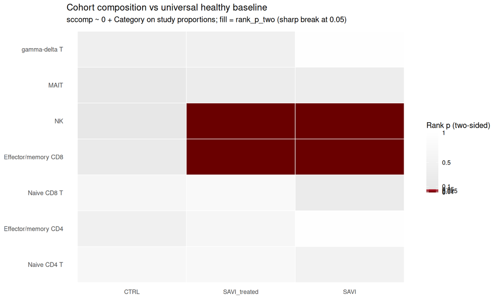

```r
comp_heat_df <- composition_cohort_vs_healthy |>
  dplyr::mutate(
    Category = factor(.data$Category, levels = cohort_levels_comp),
    paper_compartment = factor(
      .data$paper_compartment,
      levels = paper_compartment_levels
    )
  )

comp_p_heat_scale <- ggplot2::scale_fill_gradientn(
  colours = c("#6a0000", "#b2182b", "#e6e6e6", "#ffffff"),
  values = c(0, 0.05, 0.051, 1),
  limits = c(0, 1),
  oob = scales::squish,
  breaks = c(0, 0.01, 0.025, 0.05, 0.1, 0.5, 1),
  labels = c("0", "0.01", "0.025", "0.05", "0.1", "0.5", "1"),
  name = "Rank p (two-sided)"
)

ggplot2::ggplot(
  comp_heat_df,
  ggplot2::aes(
    x = .data$Category,
    y = .data$paper_compartment,
    fill = .data$rank_p_two
  )
) +
  ggplot2::geom_tile(colour = "white", linewidth = 0.3) +
  comp_p_heat_scale +
  ggplot2::labs(
    title = "Cohort composition vs universal healthy baseline",
    subtitle = "sccomp ~ 0 + Category on study proportions; fill = rank_p_two (sharp break at 0.05)",
    x = NULL,
    y = NULL
  ) +
  ggplot2::theme_minimal(base_size = 11) +
  ggplot2::theme(
    axis.text.y = ggplot2::element_text(size = 9),
    panel.grid = ggplot2::element_blank()
  )
```

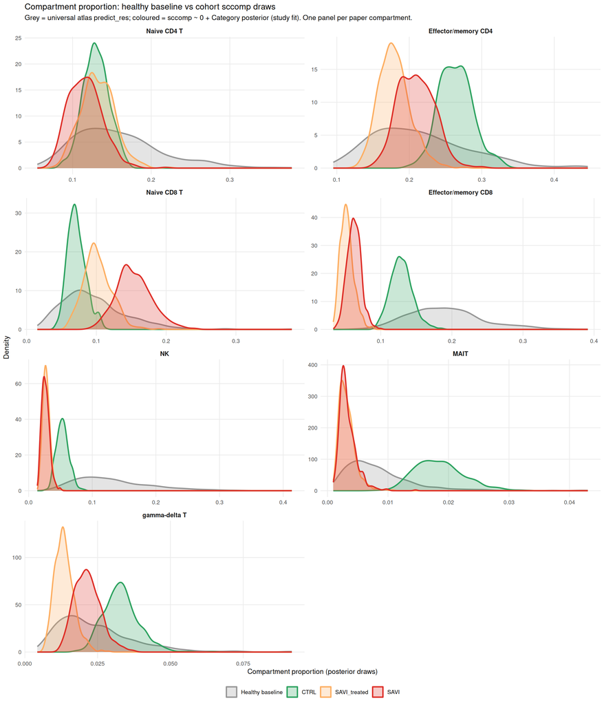

```r
comp_draw_density_df <- dplyr::bind_rows(
  baseline_compartment_draws |>
    dplyr::transmute(
      paper_compartment = .data$paper_compartment,
      comp_prop = .data$baseline_comp_prop,
      curve = "Healthy baseline"
    ),
  cohort_compartment_draws |>
    dplyr::transmute(
      paper_compartment = .data$paper_compartment,
      comp_prop = .data$cohort_comp_prop,
      curve = as.character(.data$Category)
    )
) |>
  dplyr::mutate(
    curve = factor(
      .data$curve,
      levels = c("Healthy baseline", cohort_levels_comp)
    ),
    paper_compartment = factor(
      .data$paper_compartment,
      levels = paper_compartment_levels
    )
  )

comp_curve_cols <- c(
  "Healthy baseline" = "#969696",
  CTRL = "#2ca25f",
  SAVI_treated = "#fdae61",
  SAVI = "#de2d26"
)

ggplot2::ggplot(
  comp_draw_density_df,
  ggplot2::aes(
    x = .data$comp_prop,
    colour = .data$curve,
    fill = .data$curve
  )
) +
  ggplot2::geom_density(alpha = 0.25, linewidth = 0.9) +
  ggplot2::scale_colour_manual(values = comp_curve_cols, name = NULL) +
  ggplot2::scale_fill_manual(values = comp_curve_cols, name = NULL) +
  ggplot2::facet_wrap(
    ~ paper_compartment,
    ncol = 2,
    scales = "free"
  ) +
  ggplot2::labs(
    title = "Compartment proportion: healthy baseline vs cohort sccomp draws",
    subtitle = paste(
      "Grey = universal atlas predict_res;",
      "coloured = sccomp ~ 0 + Category posterior (study fit).",
      "One panel per paper compartment."
    ),
    x = "Compartment proportion (posterior draws)",
    y = "Density"
  ) +
  ggplot2::theme_minimal(base_size = 10) +
  ggplot2::theme(
    legend.position = "bottom",
    strip.text = ggplot2::element_text(size = 9, face = "bold"),
    panel.grid.minor = ggplot2::element_blank()
  )
```

**Reading cohort-level results:** compare `composition_cohort_vs_healthy` to per-donor `composition_universal_reference`. Cohort aggregation pools donors into one compositional estimate per arm (via sccomp), so power increases and donor noise averages out — analogous to edgeR group MLE for genes. **`rank_p_upper`** / **`rank_p_lower`** are the primary tests; **`welch_p`** is a Gaussian approximation on the proportion scale. The density panels above show the same comparison visually: grey = healthy null, coloured curves = cohort posterior.

### Universal healthy baseline by paper compartment

Healthy atlas predictive draws (`predict_res`, universal null): for each **paper compartment**, sum mapped L3 proportions per draw, then summarise the **pooled** marginal predictive distribution (no sex/age stratification).

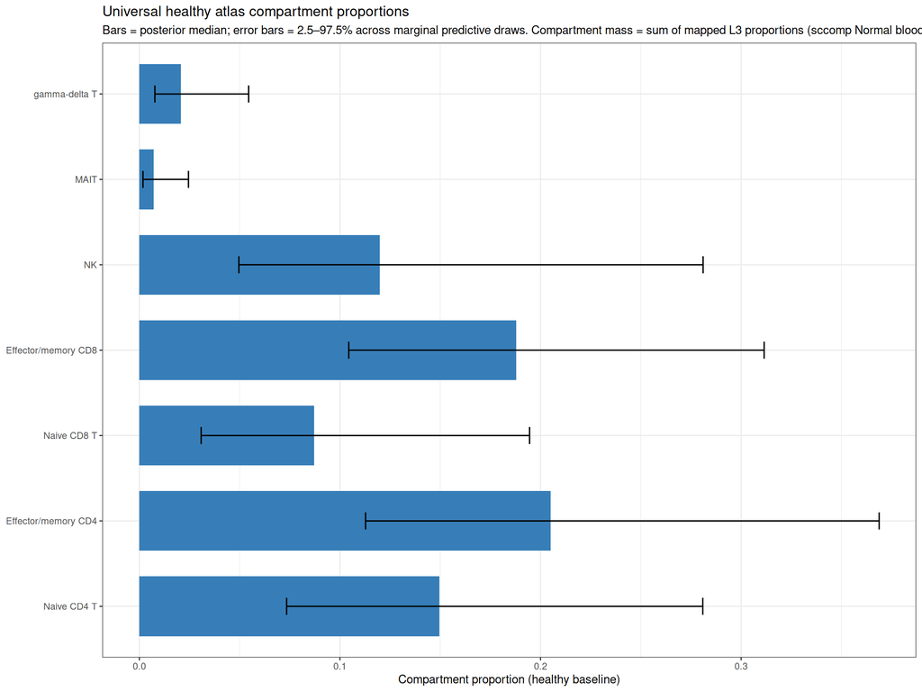

```r
healthy_baseline_compartment_universal <- predict_res |>
  dplyr::inner_join(
    paper_compartment_l3 |>
      dplyr::distinct(.data$paper_compartment, .data$cell_type),
    by = "cell_type"
  ) |>
  dplyr::group_by(.data$paper_compartment, .data$.draw) |>
  dplyr::summarise(
    compartment_proportion = sum(.data$proportion),
    .groups = "drop"
  ) |>
  dplyr::group_by(.data$paper_compartment) |>
  dplyr::summarise(
    median_proportion = stats::median(.data$compartment_proportion),
    hpd_lo = stats::quantile(.data$compartment_proportion, 0.025),
    hpd_hi = stats::quantile(.data$compartment_proportion, 0.975),
    .groups = "drop"
  ) |>
  dplyr::mutate(
    paper_compartment = factor(
      .data$paper_compartment,
      levels = paper_compartment_levels
    )
  )

ggplot2::ggplot(
  healthy_baseline_compartment_universal,
  ggplot2::aes(
    x = paper_compartment,
    y = median_proportion
  )
) +
  ggplot2::geom_col(fill = "#377EB8", width = 0.7) +
  ggplot2::geom_errorbar(
    ggplot2::aes(ymin = hpd_lo, ymax = hpd_hi),
    width = 0.2,
    linewidth = 0.6
  ) +
  ggplot2::coord_flip() +
  ggplot2::labs(
    title = "Universal healthy atlas compartment proportions",
    subtitle = paste(
      "Bars = posterior median; error bars = 2.5–97.5% across marginal predictive draws.",
      "Compartment mass = sum of mapped L3 proportions (sccomp Normal blood; NA sex/age/dataset/assay/ethnicity)."
    ),
    x = NULL,
    y = "Compartment proportion (healthy baseline)"
  ) +
  ggplot2::theme_bw()
```

### Observed composition (within cohort)

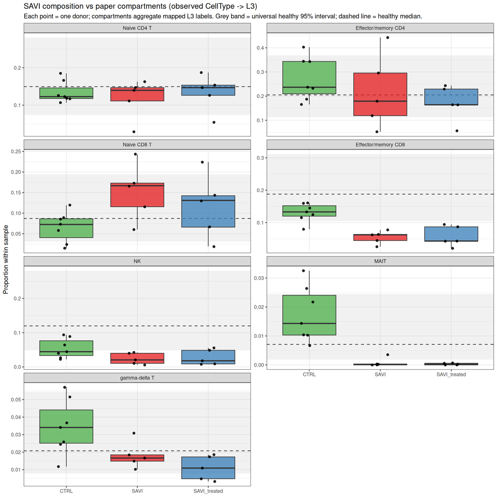

```r
category_cols <- c(
  CTRL = "#4DAF4A",
  SAVI = "#E41A1C",
  SAVI_treated = "#377EB8"
)

plot_data <- composition_paper_long |>
  dplyr::mutate(
    Category = factor(.data$Category, levels = names(category_cols)),
    paper_compartment = factor(.data$paper_compartment, levels = paper_compartment_levels)
  )

healthy_baseline_compartment_plot <- healthy_baseline_compartment_universal |>
  dplyr::mutate(
    paper_compartment = factor(
      .data$paper_compartment,
      levels = levels(plot_data$paper_compartment)
    )
  )

ggplot2::ggplot(
  plot_data,
  ggplot2::aes(
    x = Category,
    y = proportion_observed,
    fill = Category
  )
) +
  ggplot2::geom_rect(
    data = healthy_baseline_compartment_plot,
    ggplot2::aes(
      xmin = -Inf,
      xmax = Inf,
      ymin = .data$hpd_lo,
      ymax = .data$hpd_hi
    ),
    fill = "grey70",
    alpha = 0.18,
    inherit.aes = FALSE
  ) +
  ggplot2::geom_hline(
    data = healthy_baseline_compartment_plot,
    ggplot2::aes(yintercept = .data$median_proportion),
    colour = "grey25",
    linewidth = 0.6,
    linetype = "dashed",
    inherit.aes = FALSE
  ) +
  ggplot2::geom_boxplot(outlier.shape = NA, alpha = 0.75) +
  ggplot2::geom_jitter(width = 0.12, size = 1.6, alpha = 0.85) +
  ggplot2::facet_wrap(~paper_compartment, scales = "free_y", ncol = 2) +
  ggplot2::scale_fill_manual(values = category_cols) +
  ggplot2::labs(
    title = "SAVI composition vs paper compartments (observed CellType -> L3)",
    subtitle = paste(
      "Each point = one donor; compartments aggregate mapped L3 labels.",
      "Grey band = universal healthy 95% interval; dashed line = healthy median."
    ),
    x = NULL,
    y = "Proportion within sample"
  ) +
  ggplot2::theme_bw() +
  ggplot2::theme(legend.position = "none")
```

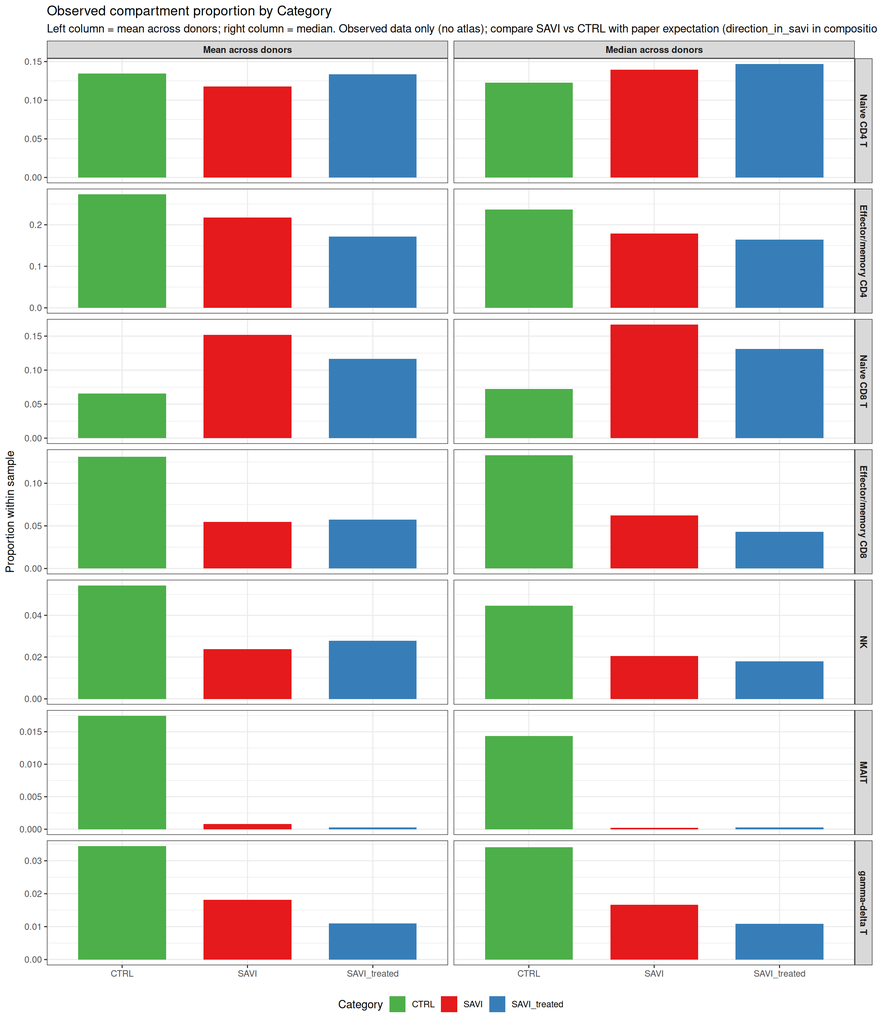

```r
composition_paper_bar <- composition_paper_summary |>
  tidyr::pivot_longer(
    cols = c(
      tidyselect::starts_with("mean_prop__"),
      tidyselect::starts_with("median_prop__")
    ),
    names_to = c("statistic", "Category"),
    names_sep = "__",
    values_to = "prop"
  ) |>
  dplyr::mutate(
    statistic = dplyr::recode(
      .data$statistic,
      mean_prop = "Mean across donors",
      median_prop = "Median across donors"
    ),
    statistic = factor(
      .data$statistic,
      levels = c("Mean across donors", "Median across donors")
    ),
    Category = factor(.data$Category, levels = names(category_cols)),
    paper_compartment = factor(.data$paper_compartment, levels = paper_compartment_levels)
  )

ggplot2::ggplot(
  composition_paper_bar,
  ggplot2::aes(x = Category, y = prop, fill = Category)
) +
  ggplot2::geom_col(position = ggplot2::position_dodge(width = 0.8), width = 0.7) +
  ggplot2::facet_grid(
    paper_compartment ~ statistic,
    scales = "free_y"
  ) +
  ggplot2::scale_fill_manual(values = category_cols) +
  ggplot2::labs(
    title = "Observed compartment proportion by Category",
    subtitle = paste(
      "Left column = mean across donors; right column = median.",
      "Observed data only (no atlas); compare SAVI vs CTRL with paper expectation",
      "(direction_in_savi in composition_paper_summary)."
    ),
    x = NULL,
    y = "Proportion within sample"
  ) +
  ggplot2::theme_bw() +
  ggplot2::theme(
    legend.position = "bottom",
    strip.text = ggplot2::element_text(size = 9, face = "bold")
  )
```

### SAVI donors vs healthy baseline (unified compartments)

For **`SAVI`** and **`SAVI_treated`** donors only, we compare each donor’s **compartment proportion** (sum of mapped L3 types) to the **universal (pooled)** healthy **`predict_res`** draws. We then ask whether the atlas tail call (`higher` / `lower` / `consistent` vs healthy) agrees with the **paper’s expected direction** in SAVI (increased vs decreased).

```r
baseline_compartment_draws <- predict_res |>
  dplyr::inner_join(
    paper_compartment_l3 |>
      dplyr::distinct(.data$paper_compartment, .data$cell_type),
    by = "cell_type"
  ) |>
  dplyr::group_by(.data$paper_compartment, .data$.draw) |>
  dplyr::summarise(
    compartment_proportion = sum(.data$proportion),
    .groups = "drop"
  )

donor_metadata_display <- example_proportions |>
  dplyr::distinct(.data$sample_id, .data$sex, .data$age_decade) |>
  dplyr::rename(sample_id_observed = sample_id)

# One reference table for all donors: tail test vs universal (pooled) healthy draws.
composition_universal_reference <- composition_paper_long |>
  dplyr::left_join(donor_metadata_display, by = "sample_id_observed") |>
  dplyr::inner_join(
    baseline_compartment_draws,
    by = "paper_compartment",
    relationship = "many-to-many"
  ) |>
  dplyr::group_by(
    .data$sample_id_observed,
    .data$Category,
    .data$sex,
    .data$age_decade,
    .data$paper_compartment,
    .data$direction_in_savi,
    .data$proportion_observed
  ) |>
  dplyr::summarise(
    healthy_median = stats::median(.data$compartment_proportion),
    healthy_hpd_lo = stats::quantile(.data$compartment_proportion, 0.025),
    healthy_hpd_hi = stats::quantile(.data$compartment_proportion, 0.975),
    p_above_healthy = mean(.data$compartment_proportion >= .data$proportion_observed),
    p_below_healthy = mean(.data$compartment_proportion <= .data$proportion_observed),
    empirical_confidence = 2 * pmin(.data$p_above_healthy, .data$p_below_healthy),
    direction_vs_healthy = dplyr::case_when(
      .data$p_above_healthy < 0.025 ~ "higher_than_healthy",
      .data$p_below_healthy < 0.025 ~ "lower_than_healthy",
      TRUE ~ "consistent_with_healthy"
    ),
    .groups = "drop"
  )

composition_savi_vs_healthy <- composition_universal_reference |>
  dplyr::filter(.data$Category %in% c("SAVI", "SAVI_treated")) |>
  dplyr::mutate(
    atlas_direction_simple = dplyr::case_when(
      .data$direction_vs_healthy == "higher_than_healthy" ~ "increased",
      .data$direction_vs_healthy == "lower_than_healthy" ~ "decreased",
      TRUE ~ "consistent"
    ),
    agrees_with_paper = dplyr::case_when(
      .data$direction_in_savi == "increased" ~
        .data$atlas_direction_simple == "increased",
      .data$direction_in_savi %in% c("decreased", "strongly decreased") ~
        .data$atlas_direction_simple == "decreased",
      TRUE ~ NA
    ),
    agreement_label = dplyr::case_when(
      .data$agrees_with_paper %in% TRUE ~ "agrees (atlas vs paper)",
      .data$agrees_with_paper %in% FALSE ~ "disagrees (atlas vs paper)",
      TRUE ~ "atlas consistent (no tail)"
    )
  )

composition_savi_vs_healthy |>
  dplyr::arrange(.data$Category, .data$paper_compartment, .data$sample_id_observed)
```

| sample_id_observed | Category | sex | age_decade | paper_compartment | direction_in_savi | proportion_observed | healthy_median | healthy_hpd_lo | healthy_hpd_hi | p_above_healthy | p_below_healthy | empirical_confidence | direction_vs_healthy | atlas_direction_simple | agrees_with_paper | agreement_label |
| --- | --- | --- | --- | --- | --- | --- | --- | --- | --- | --- | --- | --- | --- | --- | --- | --- |
| P1_STING_ht | SAVI | female | 1 | Effector/memory CD4 | decreased | 0.2958199357 | 0.205112688 | 0.112772482 | 0.36880792 | 0.132 | 0.868 | 0.264 | consistent_with_healthy | consistent | FALSE | disagrees (atlas vs paper) |
| P2_STING_ht | SAVI | male | 4 | Effector/memory CD4 | decreased | 0.4426195426 | 0.205112688 | 0.112772482 | 0.36880792 | 0.004 | 0.996 | 0.008 | higher_than_healthy | increased | FALSE | disagrees (atlas vs paper) |
| P4_STING_ht | SAVI | male | 1 | Effector/memory CD4 | decreased | 0.1791621580 | 0.205112688 | 0.112772482 | 0.36880792 | 0.664 | 0.336 | 0.672 | consistent_with_healthy | consistent | FALSE | disagrees (atlas vs paper) |
| P5_STING | SAVI | male | 1 | Effector/memory CD4 | decreased | 0.1191343964 | 0.205112688 | 0.112772482 | 0.36880792 | 0.962 | 0.038 | 0.076 | consistent_with_healthy | consistent | FALSE | disagrees (atlas vs paper) |
| P6_STING_ht | SAVI | male | 1 | Effector/memory CD4 | decreased | 0.0525285972 | 0.205112688 | 0.112772482 | 0.36880792 | 1.000 | 0.000 | 0.000 | lower_than_healthy | decreased | TRUE | agrees (atlas vs paper) |
| P1_STING_ht | SAVI | female | 1 | Effector/memory CD8 | decreased | 0.0634788922 | 0.187913433 | 0.104400322 | 0.31146722 | 0.998 | 0.002 | 0.004 | lower_than_healthy | decreased | TRUE | agrees (atlas vs paper) |
| P2_STING_ht | SAVI | male | 4 | Effector/memory CD8 | decreased | 0.0775467775 | 0.187913433 | 0.104400322 | 0.31146722 | 0.996 | 0.004 | 0.008 | lower_than_healthy | decreased | TRUE | agrees (atlas vs paper) |
| P4_STING_ht | SAVI | male | 1 | Effector/memory CD8 | decreased | 0.0446746019 | 0.187913433 | 0.104400322 | 0.31146722 | 1.000 | 0.000 | 0.000 | lower_than_healthy | decreased | TRUE | agrees (atlas vs paper) |
| P5_STING | SAVI | male | 1 | Effector/memory CD8 | decreased | 0.0624145786 | 0.187913433 | 0.104400322 | 0.31146722 | 1.000 | 0.000 | 0.000 | lower_than_healthy | decreased | TRUE | agrees (atlas vs paper) |
| P6_STING_ht | SAVI | male | 1 | Effector/memory CD8 | decreased | 0.0255869958 | 0.187913433 | 0.104400322 | 0.31146722 | 1.000 | 0.000 | 0.000 | lower_than_healthy | decreased | TRUE | agrees (atlas vs paper) |

[output cut: 60 more lines]

```r
composition_savi_agreement_summary <- composition_savi_vs_healthy |>
  dplyr::group_by(.data$Category, .data$paper_compartment, .data$direction_in_savi) |>
  dplyr::summarise(
    n_donors = dplyr::n(),
    n_higher = sum(.data$direction_vs_healthy == "higher_than_healthy"),
    n_lower = sum(.data$direction_vs_healthy == "lower_than_healthy"),
    n_consistent = sum(.data$direction_vs_healthy == "consistent_with_healthy"),
    n_agrees_paper = sum(.data$agrees_with_paper %in% TRUE, na.rm = TRUE),
    n_disagrees_paper = sum(.data$agrees_with_paper %in% FALSE, na.rm = TRUE),
    n_testable = sum(!is.na(.data$agrees_with_paper)),
    pct_agrees_paper = dplyr::if_else(
      sum(!is.na(.data$agrees_with_paper)) > 0L,
      100 * mean(.data$agrees_with_paper, na.rm = TRUE),
      NA_real_
    ),
    .groups = "drop"
  ) |>
  dplyr::arrange(.data$Category, .data$paper_compartment)

composition_savi_agreement_summary
```

| Category | paper_compartment | direction_in_savi | n_donors | n_higher | n_lower | n_consistent | n_agrees_paper | n_disagrees_paper | n_testable | pct_agrees_paper |
| --- | --- | --- | --- | --- | --- | --- | --- | --- | --- | --- |
| SAVI | Effector/memory CD4 | decreased | 5 | 1 | 1 | 3 | 1 | 4 | 5 | 20 |
| SAVI | Effector/memory CD8 | decreased | 5 | 0 | 5 | 0 | 5 | 0 | 5 | 100 |
| SAVI | MAIT | strongly decreased | 5 | 0 | 4 | 1 | 4 | 1 | 5 | 80 |
| SAVI | NK | decreased | 5 | 0 | 5 | 0 | 5 | 0 | 5 | 100 |
| SAVI | Naive CD4 T | increased | 5 | 0 | 1 | 4 | 0 | 5 | 5 | 0 |
| SAVI | Naive CD8 T | increased | 5 | 1 | 0 | 4 | 1 | 4 | 5 | 20 |
| SAVI | gamma-delta T | strongly decreased | 5 | 0 | 0 | 5 | 0 | 5 | 5 | 0 |
| SAVI_treated | Effector/memory CD4 | decreased | 5 | 0 | 1 | 4 | 1 | 4 | 5 | 20 |
| SAVI_treated | Effector/memory CD8 | decreased | 5 | 0 | 5 | 0 | 5 | 0 | 5 | 100 |
| SAVI_treated | MAIT | strongly decreased | 5 | 0 | 5 | 0 | 5 | 0 | 5 | 100 |

[output cut: 4 more lines]

```r
# Diagnostic: heatmap tail call vs observed relative to universal healthy median.
composition_naive_cd4_check <- composition_universal_reference |>
  dplyr::filter(
    .data$paper_compartment == "Naive CD4 T",
    .data$Category == "SAVI"
  ) |>
  dplyr::transmute(
    sample_id_observed,
    age_decade,
    sex,
    proportion_observed,
    healthy_median_matched = .data$healthy_median,
    delta_obs_minus_matched = .data$proportion_observed - .data$healthy_median,
    direction_vs_healthy,
    visual_check = dplyr::case_when(
      .data$direction_vs_healthy == "higher_than_healthy" ~
        "solid line should be RIGHT of dashed median",
      .data$direction_vs_healthy == "lower_than_healthy" ~
        "solid line should be LEFT of dashed median",
      TRUE ~ "solid line near dashed median"
    )
  )

composition_naive_cd4_check
```

| sample_id_observed | age_decade | sex | proportion_observed | healthy_median_matched | delta_obs_minus_matched | direction_vs_healthy | visual_check |
| --- | --- | --- | --- | --- | --- | --- | --- |
| P1_STING_ht | 1 | female | 0.14687273 | 0.1495638 | -0.002691099 | consistent_with_healthy | solid line near dashed median |
| P2_STING_ht | 4 | male | 0.16278586 | 0.1495638 | 0.013222033 | consistent_with_healthy | solid line near dashed median |
| P4_STING_ht | 1 | male | 0.13958881 | 0.1495638 | -0.009975022 | consistent_with_healthy | solid line near dashed median |
| P5_STING | 1 | male | 0.11116173 | 0.1495638 | -0.038402099 | consistent_with_healthy | solid line near dashed median |
| P6_STING_ht | 1 | male | 0.02874774 | 0.1495638 | -0.120816088 | lower_than_healthy | solid line should be LEFT of dashed median |

### How much CTRL samples in data agree with our healthy baseline

In-study **CTRL** donors are the paper’s reference for “healthy”. If they are exchangeable with the Immune Atlas **universal (marginalised)** healthy baseline, each **CTRL** pseudobulk compartment proportion should fall inside the pooled predictive null (`direction_vs_healthy == consistent_with_healthy`). Deviations flag compartments where study controls already sit above or below the atlas before comparing SAVI.

```r
composition_ctrl_baseline <- composition_universal_reference |>
  dplyr::filter(.data$Category == "CTRL") |>
  dplyr::mutate(
    agrees_with_healthy_baseline = .data$direction_vs_healthy == "consistent_with_healthy",
    baseline_agreement = dplyr::case_when(
      .data$direction_vs_healthy == "consistent_with_healthy" ~ "consistent with healthy",
      .data$direction_vs_healthy == "higher_than_healthy" ~ "higher than healthy",
      .data$direction_vs_healthy == "lower_than_healthy" ~ "lower than healthy"
    ),
    baseline_agreement = factor(
      .data$baseline_agreement,
      levels = c(
        "consistent with healthy",
        "higher than healthy",
        "lower than healthy"
      )
    ),
    atlas_strength = 1 - .data$empirical_confidence,
    direction_short = dplyr::case_when(
      .data$direction_vs_healthy == "higher_than_healthy" ~ "↑",
      .data$direction_vs_healthy == "lower_than_healthy" ~ "↓",
      TRUE ~ "·"
    ),
    tile_label = sprintf(
      "%s\n%.2f",
      .data$direction_short,
      .data$atlas_strength
    ),
    paper_compartment = factor(
      .data$paper_compartment,
      levels = paper_compartment_levels
    )
  )

composition_ctrl_baseline_summary <- composition_ctrl_baseline |>
  dplyr::group_by(.data$sample_id_observed, .data$sex, .data$age_decade) |>
  dplyr::summarise(
    n_compartments = dplyr::n(),
    n_consistent = sum(.data$agrees_with_healthy_baseline),
    n_higher = sum(.data$direction_vs_healthy == "higher_than_healthy"),
    n_lower = sum(.data$direction_vs_healthy == "lower_than_healthy"),
    pct_consistent = 100 * .data$n_consistent / .data$n_compartments,
    .groups = "drop"
  ) |>
  dplyr::arrange(dplyr::desc(.data$pct_consistent), .data$sample_id_observed)

composition_ctrl_baseline_overall <- composition_ctrl_baseline |>
  dplyr::summarise(
    n_ctrl_donors = dplyr::n_distinct(.data$sample_id_observed),
    n_tests = dplyr::n(),
    n_consistent = sum(.data$agrees_with_healthy_baseline),
    n_higher = sum(.data$direction_vs_healthy == "higher_than_healthy"),
    n_lower = sum(.data$direction_vs_healthy == "lower_than_healthy"),
    pct_consistent = 100 * .data$n_consistent / .data$n_tests,
    mean_pct_consistent_per_donor = mean(composition_ctrl_baseline_summary$pct_consistent)
  )

composition_ctrl_baseline_overall
```

| n_ctrl_donors | n_tests | n_consistent | n_higher | n_lower | pct_consistent | mean_pct_consistent_per_donor |
| --- | --- | --- | --- | --- | --- | --- |
| 7 | 49 | 38 | 4 | 7 | 77.55102 | 77.55102 |

```r
composition_ctrl_baseline_summary
```

| sample_id_observed | sex | age_decade | n_compartments | n_consistent | n_higher | n_lower | pct_consistent |
| --- | --- | --- | --- | --- | --- | --- | --- |
| C10 | male | 1 | 7 | 7 | 0 | 0 | 100.00000 |
| C11 | male | 2 | 7 | 6 | 1 | 0 | 85.71429 |
| C7 | female | 1 | 7 | 6 | 0 | 1 | 85.71429 |
| C1 | male | 4 | 7 | 5 | 0 | 2 | 71.42857 |
| C2 | male | 4 | 7 | 5 | 1 | 1 | 71.42857 |
| C9_mother_P1_STING | female | 4 | 7 | 5 | 1 | 1 | 71.42857 |
| C8_aunt_P1_STING | female | 4 | 7 | 4 | 1 | 2 | 57.14286 |

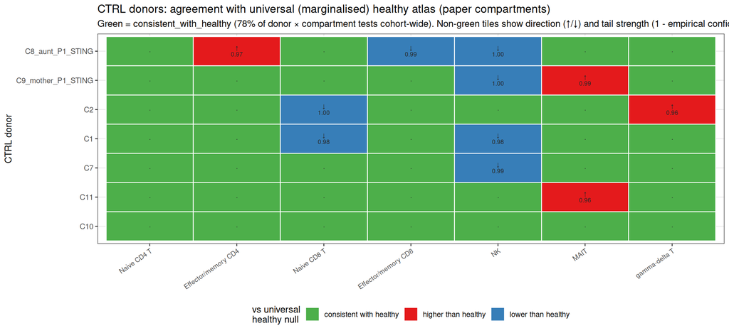

```r
ctrl_baseline_cols <- c(
  "consistent with healthy" = "#4DAF4A",
  "higher than healthy" = "#E41A1C",
  "lower than healthy" = "#377EB8"
)

ctrl_sample_order <- composition_ctrl_baseline_summary |>
  dplyr::arrange(dplyr::desc(.data$pct_consistent), .data$sample_id_observed) |>
  dplyr::pull(.data$sample_id_observed)

ctrl_heatmap_data <- composition_ctrl_baseline |>
  dplyr::mutate(
    sample_id_observed = factor(.data$sample_id_observed, levels = ctrl_sample_order),
    tile_label = dplyr::if_else(
      .data$agrees_with_healthy_baseline,
      "·",
      .data$tile_label
    )
  )

ggplot2::ggplot(
  ctrl_heatmap_data,
  ggplot2::aes(
    x = paper_compartment,
    y = sample_id_observed,
    fill = baseline_agreement
  )
) +
  ggplot2::geom_tile(color = "white", linewidth = 0.45) +
  ggplot2::geom_text(
    ggplot2::aes(label = tile_label),
    size = 2.5,
    lineheight = 0.85,
    color = "grey15"
  ) +
  ggplot2::scale_fill_manual(
    values = ctrl_baseline_cols,
    name = "vs universal\nhealthy null"
  ) +
  ggplot2::labs(
    title = "CTRL donors: agreement with universal (marginalised) healthy atlas (paper compartments)",
    subtitle = paste0(
      "Green = consistent_with_healthy (",
      sprintf("%.0f", composition_ctrl_baseline_overall$pct_consistent),
      "% of donor × compartment tests cohort-wide). ",
      "Non-green tiles show direction (↑/↓) and tail strength (1 - empirical confidence)."
    ),
    x = NULL,
    y = "CTRL donor"
  ) +
  ggplot2::theme_bw() +
  ggplot2::theme(
    axis.text.x = ggplot2::element_text(angle = 35, hjust = 1, size = 8),
    axis.text.y = ggplot2::element_text(size = 9),
    legend.position = "bottom"
  )
```

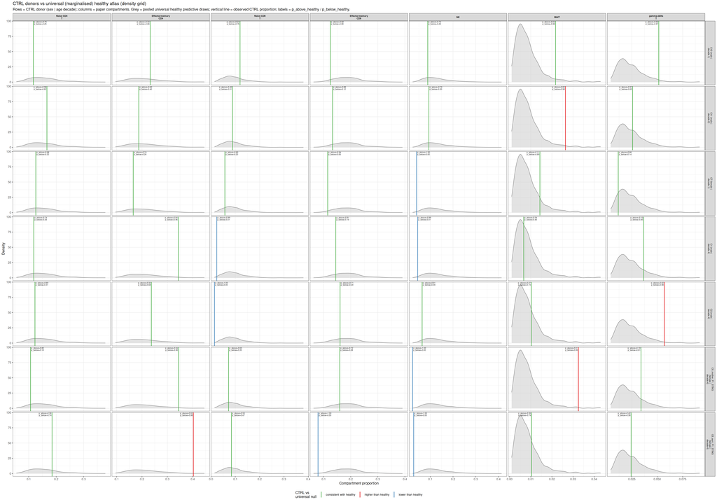

```r
compartment_levels <- paper_compartment_levels

if (!exists("baseline_compartment_draws")) {
  baseline_compartment_draws <- predict_res |>
    dplyr::inner_join(
      paper_compartment_l3 |>
        dplyr::distinct(.data$paper_compartment, .data$cell_type),
      by = "cell_type"
    ) |>
    dplyr::group_by(.data$paper_compartment, .data$.draw) |>
    dplyr::summarise(
      compartment_proportion = sum(.data$proportion),
      .groups = "drop"
    )
}

ctrl_panel_meta <- composition_ctrl_baseline |>
  dplyr::distinct(
    .data$sample_id_observed,
    .data$sex,
    .data$age_decade,
    .data$paper_compartment
  ) |>
  dplyr::mutate(
    sample_panel = paste0(
      .data$sample_id_observed,
      " (",
      .data$sex,
      " | decade ",
      .data$age_decade,
      ")"
    )
  )

ctrl_panel_order <- composition_ctrl_baseline_summary |>
  dplyr::mutate(
    sample_panel = paste0(
      .data$sample_id_observed,
      " (",
      .data$sex,
      " | decade ",
      .data$age_decade,
      ")"
    )
  ) |>
  dplyr::arrange(dplyr::desc(.data$pct_consistent), .data$sample_id_observed)

ctrl_density_draws <- ctrl_panel_meta |>
  dplyr::inner_join(
    baseline_compartment_draws,
    by = "paper_compartment"
  ) |>
  dplyr::mutate(
    sample_panel = factor(
      .data$sample_panel,
      levels = ctrl_panel_order$sample_panel
    ),
    paper_compartment = factor(.data$paper_compartment, levels = compartment_levels)
  ) |>
  dplyr::filter(
    is.finite(.data$compartment_proportion),
    .data$compartment_proportion >= 0
  )

ctrl_density_vlines <- composition_ctrl_baseline |>
  dplyr::mutate(
    sample_panel = paste0(
      .data$sample_id_observed,
      " (",
      .data$sex,
      " | decade ",
      .data$age_decade,
      ")"
    ),
    sample_panel = factor(
      .data$sample_panel,
      levels = ctrl_panel_order$sample_panel
    ),
    paper_compartment = factor(.data$paper_compartment, levels = compartment_levels),
    p_label = sprintf(
      "p_above=%.2f\np_below=%.2f",
      .data$p_above_healthy,
      .data$p_below_healthy
    )
  ) |>
  dplyr::filter(is.finite(.data$proportion_observed)) |>
  dplyr::left_join(
    ctrl_density_draws |>
      dplyr::group_by(.data$sample_panel, .data$paper_compartment) |>
      dplyr::summarise(
        x_mid = stats::median(.data$compartment_proportion, na.rm = TRUE),
        .groups = "drop"
      ),
    by = c("sample_panel", "paper_compartment")
  ) |>
  dplyr::mutate(
    text_hjust = dplyr::if_else(
      .data$proportion_observed > .data$x_mid,
      1.05,
      -0.05
    )
  )

ggplot2::ggplot(
  ctrl_density_draws,
  ggplot2::aes(x = compartment_proportion)
) +
  ggplot2::geom_density(
    fill = "grey80",
    color = "grey35",
    alpha = 0.55,
    linewidth = 0.35,
    na.rm = TRUE
  ) +
  ggplot2::geom_vline(
    data = ctrl_density_vlines,
    ggplot2::aes(
      xintercept = proportion_observed,
      color = baseline_agreement
    ),
    inherit.aes = FALSE,
    linewidth = 0.75
  ) +
  ggplot2::geom_text(
    data = ctrl_density_vlines,
    ggplot2::aes(
      x = proportion_observed,
      y = Inf,
      label = p_label,
      hjust = text_hjust
    ),
    inherit.aes = FALSE,
    vjust = 1.05,
    size = 2.1,
    lineheight = 0.85,
    color = "grey15"
  ) +
  ggplot2::facet_grid(
    sample_panel ~ paper_compartment,
    scales = "free",
    labeller = ggplot2::labeller(
      .cols = ggplot2::label_wrap_gen(10),
      .rows = ggplot2::label_wrap_gen(16)
    )
  ) +
  ggplot2::scale_color_manual(
    values = ctrl_baseline_cols,
    name = "CTRL vs\nuniversal null"
  ) +
  ggplot2::scale_x_continuous(expand = ggplot2::expansion(mult = c(0.04, 0.06))) +
  ggplot2::labs(
    title = "CTRL donors vs universal (marginalised) healthy atlas (density grid)",
    subtitle = paste(
      "Rows = CTRL donor (sex | age decade); columns = paper compartments.",
      "Grey = pooled universal healthy predictive draws;",
      "vertical line = observed CTRL proportion;",
      "labels = p_above_healthy / p_below_healthy."
    ),
    x = "Compartment proportion",
    y = "Density"
  ) +
  ggplot2::theme_bw() +
  ggplot2::theme(
    legend.position = "bottom",
    strip.text.x = ggplot2::element_text(size = 7, face = "bold"),
    strip.text.y = ggplot2::element_text(size = 7),
    panel.spacing = grid::unit(0.25, "lines")
  )
```

### Healthy atlas comparison (plots)

Tail tests and visualizations below use **universal (marginalised)** healthy **`predict_res`** draws (`composition_universal_reference`).

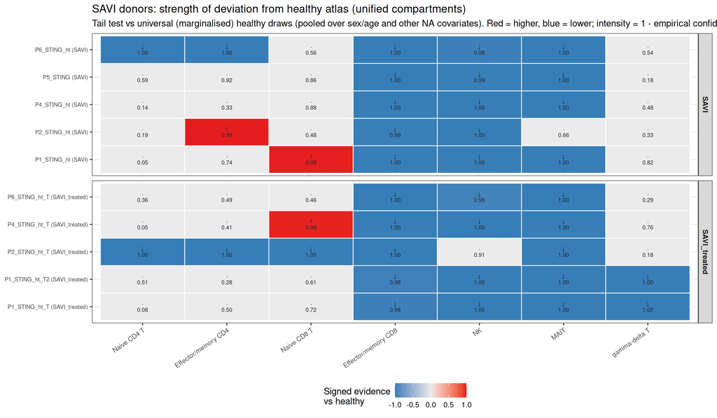

```r
# empirical_confidence = 2 * min(P(draw>=obs), P(draw<=obs)): near 0 = strong tail;
# near 1 = central. Signed score: direction x (1 - empirical_confidence).
heatmap_data <- composition_savi_vs_healthy |>
  dplyr::mutate(
    Category = factor(.data$Category, levels = c("SAVI", "SAVI_treated")),
    atlas_strength = 1 - .data$empirical_confidence,
    atlas_signed_score = dplyr::case_when(
      .data$direction_vs_healthy == "higher_than_healthy" ~ .data$atlas_strength,
      .data$direction_vs_healthy == "lower_than_healthy" ~ -.data$atlas_strength,
      TRUE ~ 0
    ),
    direction_short = dplyr::case_when(
      .data$direction_vs_healthy == "higher_than_healthy" ~ "↑",
      .data$direction_vs_healthy == "lower_than_healthy" ~ "↓",
      TRUE ~ "·"
    ),
    tile_label = sprintf(
      "%s\n%.2f",
      .data$direction_short,
      .data$atlas_strength
    ),
    sample_label = paste0(.data$sample_id_observed, " (", .data$Category, ")"),
    paper_compartment = factor(
      .data$paper_compartment,
      levels = paper_compartment_levels
    )
  )

score_lim <- max(abs(heatmap_data$atlas_signed_score), na.rm = TRUE)
score_lim <- if (is.finite(score_lim) && score_lim > 0) score_lim else 1

ggplot2::ggplot(
  heatmap_data,
  ggplot2::aes(
    x = paper_compartment,
    y = sample_label,
    fill = atlas_signed_score
  )
) +
  ggplot2::geom_tile(color = "white", linewidth = 0.4) +
  ggplot2::geom_text(
    ggplot2::aes(label = tile_label),
    size = 2.4,
    lineheight = 0.85,
    color = "grey15"
  ) +
  ggplot2::scale_fill_gradient2(
    low = "#377EB8",
    mid = "grey92",
    high = "#E41A1C",
    midpoint = 0,
    limits = c(-score_lim, score_lim),
    oob = scales::squish,
    name = "Signed evidence\nvs healthy"
  ) +
  ggplot2::facet_grid(.data$Category ~ ., scales = "free_y", space = "free_y") +
  ggplot2::labs(
    title = "SAVI donors: strength of deviation from healthy atlas (unified compartments)",
    subtitle = paste(
      "Tail test vs universal (marginalised) healthy draws (pooled over sex/age and other NA covariates).",
      "Red = higher, blue = lower; intensity = 1 - empirical confidence."
    ),
    x = NULL,
    y = NULL
  ) +
  ggplot2::theme_bw() +
  ggplot2::theme(
    axis.text.x = ggplot2::element_text(angle = 35, hjust = 1, size = 8),
    axis.text.y = ggplot2::element_text(size = 7),
    strip.text = ggplot2::element_text(face = "bold"),
    legend.position = "bottom"
  )
```

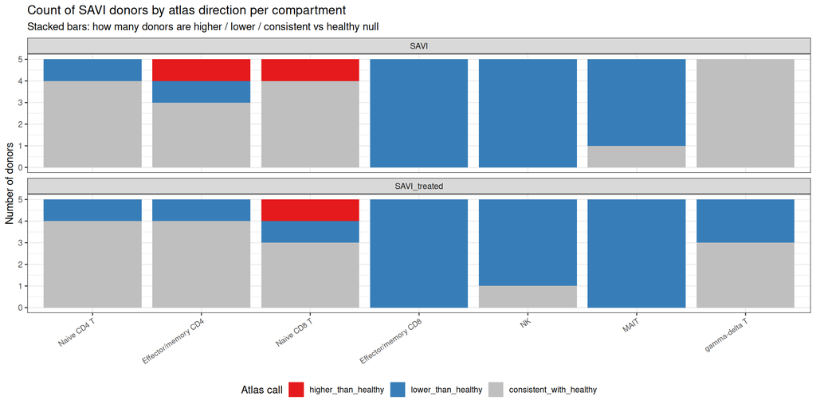

```r
direction_cols <- c(
  higher_than_healthy = "#E41A1C",
  lower_than_healthy = "#377EB8",
  consistent_with_healthy = "grey75"
)

count_long <- composition_savi_agreement_summary |>
  tidyr::pivot_longer(
    cols = c(n_higher, n_lower, n_consistent),
    names_to = "atlas_call",
    values_to = "n"
  ) |>
  dplyr::mutate(
    Category = factor(.data$Category, levels = c("SAVI", "SAVI_treated")),
    paper_compartment = factor(.data$paper_compartment, levels = paper_compartment_levels),
    atlas_call = dplyr::recode(
      .data$atlas_call,
      n_higher = "higher_than_healthy",
      n_lower = "lower_than_healthy",
      n_consistent = "consistent_with_healthy"
    ),
    atlas_call = factor(.data$atlas_call, levels = names(direction_cols))
  )

ggplot2::ggplot(
  count_long,
  ggplot2::aes(x = paper_compartment, y = n, fill = atlas_call)
) +
  ggplot2::geom_col(position = "stack") +
  ggplot2::facet_wrap(~Category, ncol = 1) +
  ggplot2::scale_fill_manual(values = direction_cols, name = "Atlas call") +
  ggplot2::labs(
    title = "Count of SAVI donors by atlas direction per compartment",
    subtitle = "Stacked bars: how many donors are higher / lower / consistent vs healthy null",
    x = NULL,
    y = "Number of donors"
  ) +
  ggplot2::theme_bw() +
  ggplot2::theme(
    axis.text.x = ggplot2::element_text(angle = 35, hjust = 1, size = 8),
    legend.position = "bottom"
  )
```

[figure not shown]

```r
agreement_cols <- c(
  "agrees (atlas vs paper)" = "#4DAF4A",
  "disagrees (atlas vs paper)" = "#FF7F00",
  "atlas consistent (no tail)" = "grey70"
)

ggplot2::ggplot(
  composition_savi_vs_healthy |>
    dplyr::mutate(
      Category = factor(.data$Category, levels = c("SAVI", "SAVI_treated")),
      paper_compartment = factor(.data$paper_compartment, levels = paper_compartment_levels),
      agreement_label = factor(.data$agreement_label, levels = names(agreement_cols))
    ),
  ggplot2::aes(x = paper_compartment, fill = agreement_label)
) +
  ggplot2::geom_bar(position = "fill") +
  ggplot2::facet_wrap(~Category, ncol = 1) +
  ggplot2::scale_fill_manual(values = agreement_cols, name = "Agreement") +
  ggplot2::scale_y_continuous(labels = scales::percent_format()) +
  ggplot2::labs(
    title = "Atlas vs paper agreement (SAVI donors, unified compartments)",
    subtitle = paste(
      "Paper expects increased (naive CD4/CD8) or decreased (effector/memory, NK, MAIT, gdT).",
      "Green = atlas tail matches paper direction; orange = opposite tail."
    ),
    x = NULL,
    y = "Fraction of donors"
  ) +
  ggplot2::theme_bw() +
  ggplot2::theme(
    axis.text.x = ggplot2::element_text(angle = 35, hjust = 1, size = 8),
    legend.position = "bottom"
  )
```

[figure not shown]

```r
ggplot2::ggplot(
  composition_savi_agreement_summary |>
    dplyr::mutate(
      Category = factor(.data$Category, levels = c("SAVI", "SAVI_treated")),
      paper_compartment = factor(
        .data$paper_compartment,
        levels = paper_compartment_levels
      )
    ),
  ggplot2::aes(
    x = paper_compartment,
    y = pct_agrees_paper,
    fill = Category
  )
) +
  ggplot2::geom_col(position = ggplot2::position_dodge(width = 0.75), width = 0.65) +
  ggplot2::geom_hline(yintercept = 50, linetype = "dashed", color = "grey50") +
  ggplot2::scale_fill_manual(values = c(SAVI = "#E41A1C", SAVI_treated = "#377EB8")) +
  ggplot2::scale_y_continuous(limits = c(0, 100), expand = ggplot2::expansion(mult = c(0, 0.02))) +
  ggplot2::labs(
    title = "Share of SAVI donors where atlas tail agrees with paper",
    subtitle = "Among donors with a clear atlas tail (excludes 'consistent' only when testing agreement)",
    x = NULL,
    y = "% donors agreeing with paper direction"
  ) +
  ggplot2::theme_bw() +
  ggplot2::theme(axis.text.x = ggplot2::element_text(angle = 35, hjust = 1, size = 8))
```

### Compartment density vs universal healthy null

Same layout as the **CTRL** density grid (`plot-composition-ctrl-baseline-density`): one panel per **donor × paper compartment**. Grey density = **pooled** universal healthy **`predict_res`** draws (same null for every donor); vertical line = observed proportion with tail colours and **`p_above_healthy`** / **`p_below_healthy`** labels. Below: **SAVI** and **SAVI_treated** donors only.

```r
compartment_levels <- paper_compartment_levels

atlas_null_cols <- c(
  "consistent with healthy" = "#4DAF4A",
  "higher than healthy" = "#E41A1C",
  "lower than healthy" = "#377EB8"
)

if (!exists("baseline_compartment_draws")) {
  baseline_compartment_draws <- predict_res |>
    dplyr::inner_join(
      paper_compartment_l3 |>
        dplyr::distinct(.data$paper_compartment, .data$cell_type),
      by = "cell_type"
    ) |>
    dplyr::group_by(.data$paper_compartment, .data$.draw) |>
    dplyr::summarise(
      compartment_proportion = sum(.data$proportion),
      .groups = "drop"
    )
}

savi_cohort_atlas <- composition_universal_reference |>
  dplyr::filter(.data$Category %in% c("SAVI", "SAVI_treated")) |>
  dplyr::mutate(
    baseline_agreement = dplyr::case_when(
      .data$direction_vs_healthy == "consistent_with_healthy" ~ "consistent with healthy",
      .data$direction_vs_healthy == "higher_than_healthy" ~ "higher than healthy",
      .data$direction_vs_healthy == "lower_than_healthy" ~ "lower than healthy"
    ),
    baseline_agreement = factor(
      .data$baseline_agreement,
      levels = names(atlas_null_cols)
    ),
    sample_panel = paste0(
      .data$sample_id_observed,
      " (",
      .data$Category,
      " · ",
      .data$sex,
      " | decade ",
      .data$age_decade,
      ")"
    )
  )

savi_panel_order <- savi_cohort_atlas |>
  dplyr::distinct(.data$sample_panel, .data$Category, .data$sample_id_observed) |>
  dplyr::mutate(
    Category = factor(.data$Category, levels = c("SAVI", "SAVI_treated"))
  ) |>
  dplyr::arrange(.data$Category, .data$sample_id_observed)

savi_panel_meta <- savi_cohort_atlas |>
  dplyr::distinct(
    .data$sample_id_observed,
    .data$Category,
    .data$sex,
    .data$age_decade,
    .data$paper_compartment,
    .data$sample_panel
  )

savi_density_draws <- savi_panel_meta |>
  dplyr::inner_join(
    baseline_compartment_draws,
    by = "paper_compartment"
  ) |>
  dplyr::mutate(
    sample_panel = factor(
      .data$sample_panel,
      levels = savi_panel_order$sample_panel
    ),
    paper_compartment = factor(.data$paper_compartment, levels = compartment_levels)
  ) |>
  dplyr::filter(
    is.finite(.data$compartment_proportion),
    .data$compartment_proportion >= 0
  )

savi_density_vlines <- savi_cohort_atlas |>
  dplyr::mutate(
    sample_panel = factor(
      .data$sample_panel,
      levels = savi_panel_order$sample_panel
    ),
    paper_compartment = factor(.data$paper_compartment, levels = compartment_levels),
    p_label = sprintf(
      "p_above=%.2f\np_below=%.2f",
      .data$p_above_healthy,
      .data$p_below_healthy
    )
  ) |>
  dplyr::filter(is.finite(.data$proportion_observed)) |>
  dplyr::left_join(
    savi_density_draws |>
      dplyr::group_by(.data$sample_panel, .data$paper_compartment) |>
      dplyr::summarise(
        x_mid = stats::median(.data$compartment_proportion, na.rm = TRUE),
        .groups = "drop"
      ),
    by = c("sample_panel", "paper_compartment")
  ) |>
  dplyr::mutate(
    text_hjust = dplyr::if_else(
      .data$proportion_observed > .data$x_mid,
      1.05,
      -0.05
    )
  )

ggplot2::ggplot(
  savi_density_draws,
  ggplot2::aes(x = compartment_proportion)
) +
  ggplot2::geom_density(
    fill = "grey80",
    color = "grey35",
    alpha = 0.55,
    linewidth = 0.35,
    na.rm = TRUE
  ) +
  ggplot2::geom_vline(
    data = savi_density_vlines,
    ggplot2::aes(
      xintercept = proportion_observed,
      color = baseline_agreement
    ),
    inherit.aes = FALSE,
    linewidth = 0.75
  ) +
  ggplot2::geom_text(
    data = savi_density_vlines,
    ggplot2::aes(
      x = proportion_observed,
      y = Inf,
      label = p_label,
      hjust = text_hjust
    ),
    inherit.aes = FALSE,
    vjust = 1.05,
    size = 2.1,
    lineheight = 0.85,
    color = "grey15"
  ) +
  ggplot2::facet_grid(
    sample_panel ~ paper_compartment,
    scales = "free",
    labeller = ggplot2::labeller(
      .cols = ggplot2::label_wrap_gen(10),
      .rows = ggplot2::label_wrap_gen(16)
    )
  ) +
  ggplot2::scale_color_manual(
    values = atlas_null_cols,
    name = "Donor vs\nuniversal null"
  ) +
  ggplot2::scale_x_continuous(expand = ggplot2::expansion(mult = c(0.04, 0.06))) +
  ggplot2::labs(
    title = "SAVI and SAVI_treated donors vs universal (marginalised) healthy atlas (density grid)",
    subtitle = paste(
      "Rows = donor (Category · sex | age decade); columns = paper compartments.",
      "Grey = pooled universal healthy predictive draws;",
      "vertical line = observed proportion;",
      "labels = p_above_healthy / p_below_healthy."
    ),
    x = "Compartment proportion",
    y = "Density"
  ) +
  ggplot2::theme_bw() +
  ggplot2::theme(
    legend.position = "bottom",
    strip.text.x = ggplot2::element_text(size = 7, face = "bold"),
    strip.text.y = ggplot2::element_text(size = 7),
    panel.spacing = grid::unit(0.25, "lines")
  )
```

[figure not shown]

**How to read vs the paper**

1. **Observed cohort trends** (boxplot / bar chart): within-study CTRL vs SAVI vs SAVI_treated using observed proportions only (paper Figure 1E style). **`composition_paper_summary`**: `delta_savi_minus_ctrl` and `matches_paper_savi` flag agreement with published SAVI vs control direction.
2. **Cohort-level sccomp fit** (`composition-sccomp-cohort-fit`, `composition_cohort_vs_healthy`, `plot-composition-cohort-vs-healthy-density`): group-means compositional model `~ 0 + Category` on study proportions; rank + Welch tests vs universal healthy baseline; density overlay of baseline vs cohort draws per compartment.
3. **Universal healthy baseline** (`plot-composition-healthy-baseline-universal`): pooled compartment medians and 95% predictive intervals from marginalised **`predict_res`** draws.
4. **CTRL vs atlas** (`plot-composition-ctrl-baseline-heatmap`, `plot-composition-ctrl-baseline-density`): sample × compartment heatmap plus per-donor density grid — grey curve = universal healthy draws; line = observed CTRL proportion.
5. **Healthy atlas comparison** (heatmap, count/agreement bars): per donor × compartment tail test vs universal **`predict_res`** draws (`composition_universal_reference`, `composition_savi_vs_healthy`).
6. **Compartment density plot** (`plot-composition-compartment-density`): same donor × compartment grid as CTRL — universal healthy density, tail-coloured line, **p_above** / **p_below** labels (**SAVI** and **SAVI_treated**).
7. **Fine-grained L3 table** (`composition_vs_healthy`): per donor × L3, `direction` and `empirical_confidence` with the same tail convention as gene-level deviation tests.